# Project: Identify Customer Segments

In this project, you will apply unsupervised learning techniques to identify segments of the population that form the core customer base for a mail-order sales company in Germany. These segments can then be used to direct marketing campaigns towards audiences that will have the highest expected rate of returns. The data that you will use has been provided by our partners at Bertelsmann Arvato Analytics, and represents a real-life data science task.

This notebook will help you complete this task by providing a framework within which you will perform your analysis steps. In each step of the project, you will see some text describing the subtask that you will perform, followed by one or more code cells for you to complete your work. **Feel free to add additional code and markdown cells as you go along so that you can explore everything in precise chunks.** The code cells provided in the base template will outline only the major tasks, and will usually not be enough to cover all of the minor tasks that comprise it.

It should be noted that while there will be precise guidelines on how you should handle certain tasks in the project, there will also be places where an exact specification is not provided. **There will be times in the project where you will need to make and justify your own decisions on how to treat the data.** These are places where there may not be only one way to handle the data. In real-life tasks, there may be many valid ways to approach an analysis task. One of the most important things you can do is clearly document your approach so that other scientists can understand the decisions you've made.

At the end of most sections, there will be a Markdown cell labeled **Discussion**. In these cells, you will report your findings for the completed section, as well as document the decisions that you made in your approach to each subtask. **Your project will be evaluated not just on the code used to complete the tasks outlined, but also your communication about your observations and conclusions at each stage.**

```python
# import libraries here; add more as necessary
import numpy as np
import pandas as pd
import matplotlib.pyplot as plt
import seaborn as sns

# magic word for producing visualizations in notebook
%matplotlib inline

'''
Import note: The classroom currently uses sklearn version 0.19.
If you need to use an imputer, it is available in sklearn.preprocessing.Imputer,
instead of sklearn.impute as in newer versions of sklearn.
'''
```

```
'\nImport note: The classroom currently uses sklearn version 0.19.\nIf you need to use an imputer, it is available in sklearn.preprocessing.Imputer,\ninstead of sklearn.impute as in newer versions of sklearn.\n'
```

### Step 0: Load the Data

There are four files associated with this project (not including this one):

Each row of the demographics files represents a single person, but also includes information outside of individuals, including information about their household, building, and neighborhood. You will use this information to cluster the general population into groups with similar demographic properties. Then, you will see how the people in the customers dataset fit into those created clusters. The hope here is that certain clusters are over-represented in the customers data, as compared to the general population; those over-represented clusters will be assumed to be part of the core userbase. This information can then be used for further applications, such as targeting for a marketing campaign.

To start off with, load in the demographics data for the general population into a pandas DataFrame, and do the same for the feature attributes summary. Note for all of the `.csv` data files in this project: they're semicolon (`;`) delimited, so you'll need an additional argument in your [`read_csv()`](https://pandas.pydata.org/pandas-docs/stable/generated/pandas.read_csv.html) call to read in the data properly. Also, considering the size of the main dataset, it may take some time for it to load completely.

Once the dataset is loaded, it's recommended that you take a little bit of time just browsing the general structure of the dataset and feature summary file. You'll be getting deep into the innards of the cleaning in the first major step of the project, so gaining some general familiarity can help you get your bearings.

```python
# Load in the general demographics data.
azdias = pd.read_csv("./Udacity_AZDIAS_Subset.csv", sep=";")

# Load in the feature summary file.
feat_info = pd.read_csv("./AZDIAS_Feature_Summary.csv", sep=";")
```

```python
# Check the structure of the data after it's loaded (e.g. print the number of
# rows and columns, print the first few rows).
print("Shape: ", azdias.shape)
azdias.head()
```

```
Shape:  (891221, 85)
```

|  | AGER_TYP | ALTERSKATEGORIE_GROB | ANREDE_KZ | CJT_GESAMTTYP | FINANZ_MINIMALIST | FINANZ_SPARER | FINANZ_VORSORGER | FINANZ_ANLEGER | FINANZ_UNAUFFAELLIGER | FINANZ_HAUSBAUER | ... | PLZ8_ANTG1 | PLZ8_ANTG2 | PLZ8_ANTG3 | PLZ8_ANTG4 | PLZ8_BAUMAX | PLZ8_HHZ | PLZ8_GBZ | ARBEIT | ORTSGR_KLS9 | RELAT_AB |
| --- | --- | --- | --- | --- | --- | --- | --- | --- | --- | --- | --- | --- | --- | --- | --- | --- | --- | --- | --- | --- | --- |
| 0 | -1 | 2 | 1 | 2.0 | 3 | 4 | 3 | 5 | 5 | 3 | ... | NaN | NaN | NaN | NaN | NaN | NaN | NaN | NaN | NaN | NaN |
| 1 | -1 | 1 | 2 | 5.0 | 1 | 5 | 2 | 5 | 4 | 5 | ... | 2.0 | 3.0 | 2.0 | 1.0 | 1.0 | 5.0 | 4.0 | 3.0 | 5.0 | 4.0 |
| 2 | -1 | 3 | 2 | 3.0 | 1 | 4 | 1 | 2 | 3 | 5 | ... | 3.0 | 3.0 | 1.0 | 0.0 | 1.0 | 4.0 | 4.0 | 3.0 | 5.0 | 2.0 |
| 3 | 2 | 4 | 2 | 2.0 | 4 | 2 | 5 | 2 | 1 | 2 | ... | 2.0 | 2.0 | 2.0 | 0.0 | 1.0 | 3.0 | 4.0 | 2.0 | 3.0 | 3.0 |
| 4 | -1 | 3 | 1 | 5.0 | 4 | 3 | 4 | 1 | 3 | 2 | ... | 2.0 | 4.0 | 2.0 | 1.0 | 2.0 | 3.0 | 3.0 | 4.0 | 6.0 | 5.0 |

5 rows × 85 columns

```python
print("Print: ",feat_info.shape)
print("Columns: ", feat_info.columns)
feat_info.head()
```

```
Print:  (85, 4)
Columns:  Index(['attribute', 'information_level', 'type', 'missing_or_unknown'], dtype='object')
```

|  | attribute | information_level | type | missing_or_unknown |
| --- | --- | --- | --- | --- |
| 0 | AGER_TYP | person | categorical | [-1,0] |
| 1 | ALTERSKATEGORIE_GROB | person | ordinal | [-1,0,9] |
| 2 | ANREDE_KZ | person | categorical | [-1,0] |
| 3 | CJT_GESAMTTYP | person | categorical | [0] |
| 4 | FINANZ_MINIMALIST | person | ordinal | [-1] |

```python
feat_info[feat_info["attribute"]=="GFK_URLAUBERTYP"]

# Mixed CAMEO_INTL_2015
s=    feat_info[feat_info["attribute"]=="CAMEO_INTL_2015"]["missing_or_unknown"]
type(s)
type(list(s))
list(s)
s.keys()

s.values[0]
```

```
'[-1,XX]'
```

```python
azdias["CAMEO_INTL_2015"].unique()
```

```
array([nan, '51', '24', '12', '43', '54', '22', '14', '13', '15', '33',
       '41', '34', '55', '25', '23', '31', '52', '35', '45', '44', '32',
       'XX'], dtype=object)
```

> **Tip**: Add additional cells to keep everything in reasonably-sized chunks! Keyboard shortcut `esc --> a` (press escape to enter command mode, then press the 'A' key) adds a new cell before the active cell, and `esc --> b` adds a new cell after the active cell. If you need to convert an active cell to a markdown cell, use `esc --> m` and to convert to a code cell, use `esc --> y`.

## Step 1: Preprocessing

### Step 1.1: Assess Missing Data

The feature summary file contains a summary of properties for each demographics data column. You will use this file to help you make cleaning decisions during this stage of the project. First of all, you should assess the demographics data in terms of missing data. Pay attention to the following points as you perform your analysis, and take notes on what you observe. Make sure that you fill in the **Discussion** cell with your findings and decisions at the end of each step that has one!

#### Step 1.1.1: Convert Missing Value Codes to NaNs

The fourth column of the feature attributes summary (loaded in above as `feat_info`) documents the codes from the data dictionary that indicate missing or unknown data. While the file encodes this as a list (e.g. `[-1,0]`), this will get read in as a string object. You'll need to do a little bit of parsing to make use of it to identify and clean the data. Convert data that matches a 'missing' or 'unknown' value code into a numpy NaN value. You might want to see how much data takes on a 'missing' or 'unknown' code, and how much data is naturally missing, as a point of interest.

**As one more reminder, you are encouraged to add additional cells to break up your analysis into manageable chunks.**

```python
# Identify missing or unknown data values and convert them to NaNs.
def get_missing_list(attribute_name):
    # Extract raw object
    missing_or_unknown_object = feat_info[(feat_info["attribute"] == attribute_name)]["missing_or_unknown"]

    # Convert it to a list of string, removing [, ] and ,
    missing_or_unknown_string_list = list(missing_or_unknown_object)[0]
    missing_or_unknown_string_list = missing_or_unknown_string_list.replace("[", "").replace("]","").split(",")

    # Convert elements to int, if exists (not empty string)
    missing_or_unknown_list=[]
    for i in (missing_or_unknown_string_list):
        if i != "":
            try:
                missing_or_unknown_list.append(int(i))
            except :
                missing_or_unknown_list.append(i)

    return missing_or_unknown_list

# Examples
print("List: AGER_TYP",get_missing_list("AGER_TYP"))
print("List: ALTERSKATEGORIE_GROB",get_missing_list("ALTERSKATEGORIE_GROB"))
print("List: GFK_URLAUBERTYP",get_missing_list("GFK_URLAUBERTYP"))
print("List: CAMEO_INTL_2015",get_missing_list("CAMEO_INTL_2015"))
```

```
List: AGER_TYP [-1, 0]
List: ALTERSKATEGORIE_GROB [-1, 0, 9]
List: GFK_URLAUBERTYP []
List: CAMEO_INTL_2015 [-1, 'XX']
```

```python
def replace_missing(df, attribute_name):
    # Get serie
    df_raw = df.copy()
    serie = df_raw[attribute_name]

    # Get missing mask
    missing_or_unknown_list = get_missing_list(attribute_name)
    missing_mask = serie.isin(missing_or_unknown_list)

    # Replace by NaN
    # By default, where replace other by NaN
    df_raw[attribute_name].where( missing_mask == False, inplace=True)

    return df_raw

df = azdias.copy()

df = replace_missing(df,"AGER_TYP")
df.describe()
```

|  | AGER_TYP | ALTERSKATEGORIE_GROB | ANREDE_KZ | CJT_GESAMTTYP | FINANZ_MINIMALIST | FINANZ_SPARER | FINANZ_VORSORGER | FINANZ_ANLEGER | FINANZ_UNAUFFAELLIGER | FINANZ_HAUSBAUER | ... | PLZ8_ANTG1 | PLZ8_ANTG2 | PLZ8_ANTG3 | PLZ8_ANTG4 | PLZ8_BAUMAX | PLZ8_HHZ | PLZ8_GBZ | ARBEIT | ORTSGR_KLS9 | RELAT_AB |
| --- | --- | --- | --- | --- | --- | --- | --- | --- | --- | --- | --- | --- | --- | --- | --- | --- | --- | --- | --- | --- | --- |
| count | 205378.000000 | 891221.000000 | 891221.000000 | 886367.000000 | 891221.000000 | 891221.000000 | 891221.000000 | 891221.000000 | 891221.000000 | 891221.000000 | ... | 774706.000000 | 774706.000000 | 774706.000000 | 774706.000000 | 774706.000000 | 774706.000000 | 774706.000000 | 794005.000000 | 794005.000000 | 794005.00000 |
| mean | 1.743410 | 2.777398 | 1.522098 | 3.632838 | 3.074528 | 2.821039 | 3.401106 | 3.033328 | 2.874167 | 3.075121 | ... | 2.253330 | 2.801858 | 1.595426 | 0.699166 | 1.943913 | 3.612821 | 3.381087 | 3.167854 | 5.293002 | 3.07222 |
| std | 0.674312 | 1.068775 | 0.499512 | 1.595021 | 1.321055 | 1.464749 | 1.322134 | 1.529603 | 1.486731 | 1.353248 | ... | 0.972008 | 0.920309 | 0.986736 | 0.727137 | 1.459654 | 0.973967 | 1.111598 | 1.002376 | 2.303739 | 1.36298 |
| min | 1.000000 | 1.000000 | 1.000000 | 1.000000 | 1.000000 | 1.000000 | 1.000000 | 1.000000 | 1.000000 | 1.000000 | ... | 0.000000 | 0.000000 | 0.000000 | 0.000000 | 1.000000 | 1.000000 | 1.000000 | 1.000000 | 0.000000 | 1.00000 |
| 25% | 1.000000 | 2.000000 | 1.000000 | 2.000000 | 2.000000 | 1.000000 | 3.000000 | 2.000000 | 2.000000 | 2.000000 | ... | 1.000000 | 2.000000 | 1.000000 | 0.000000 | 1.000000 | 3.000000 | 3.000000 | 3.000000 | 4.000000 | 2.00000 |
| 50% | 2.000000 | 3.000000 | 2.000000 | 4.000000 | 3.000000 | 3.000000 | 3.000000 | 3.000000 | 3.000000 | 3.000000 | ... | 2.000000 | 3.000000 | 2.000000 | 1.000000 | 1.000000 | 4.000000 | 3.000000 | 3.000000 | 5.000000 | 3.00000 |
| 75% | 2.000000 | 4.000000 | 2.000000 | 5.000000 | 4.000000 | 4.000000 | 5.000000 | 5.000000 | 4.000000 | 4.000000 | ... | 3.000000 | 3.000000 | 2.000000 | 1.000000 | 3.000000 | 4.000000 | 4.000000 | 4.000000 | 7.000000 | 4.00000 |
| max | 3.000000 | 9.000000 | 2.000000 | 6.000000 | 5.000000 | 5.000000 | 5.000000 | 5.000000 | 5.000000 | 5.000000 | ... | 4.000000 | 4.000000 | 3.000000 | 2.000000 | 5.000000 | 5.000000 | 5.000000 | 9.000000 | 9.000000 | 9.00000 |

8 rows × 81 columns

```python
df.head()
```

|  | AGER_TYP | ALTERSKATEGORIE_GROB | ANREDE_KZ | CJT_GESAMTTYP | FINANZ_MINIMALIST | FINANZ_SPARER | FINANZ_VORSORGER | FINANZ_ANLEGER | FINANZ_UNAUFFAELLIGER | FINANZ_HAUSBAUER | ... | PLZ8_ANTG1 | PLZ8_ANTG2 | PLZ8_ANTG3 | PLZ8_ANTG4 | PLZ8_BAUMAX | PLZ8_HHZ | PLZ8_GBZ | ARBEIT | ORTSGR_KLS9 | RELAT_AB |
| --- | --- | --- | --- | --- | --- | --- | --- | --- | --- | --- | --- | --- | --- | --- | --- | --- | --- | --- | --- | --- | --- |
| 0 | NaN | 2 | 1 | 2.0 | 3 | 4 | 3 | 5 | 5 | 3 | ... | NaN | NaN | NaN | NaN | NaN | NaN | NaN | NaN | NaN | NaN |
| 1 | NaN | 1 | 2 | 5.0 | 1 | 5 | 2 | 5 | 4 | 5 | ... | 2.0 | 3.0 | 2.0 | 1.0 | 1.0 | 5.0 | 4.0 | 3.0 | 5.0 | 4.0 |
| 2 | NaN | 3 | 2 | 3.0 | 1 | 4 | 1 | 2 | 3 | 5 | ... | 3.0 | 3.0 | 1.0 | 0.0 | 1.0 | 4.0 | 4.0 | 3.0 | 5.0 | 2.0 |
| 3 | 2.0 | 4 | 2 | 2.0 | 4 | 2 | 5 | 2 | 1 | 2 | ... | 2.0 | 2.0 | 2.0 | 0.0 | 1.0 | 3.0 | 4.0 | 2.0 | 3.0 | 3.0 |
| 4 | NaN | 3 | 1 | 5.0 | 4 | 3 | 4 | 1 | 3 | 2 | ... | 2.0 | 4.0 | 2.0 | 1.0 | 2.0 | 3.0 | 3.0 | 4.0 | 6.0 | 5.0 |

5 rows × 85 columns

```python
df = replace_missing(df,"ALTERSKATEGORIE_GROB")
df.describe()
```

|  | AGER_TYP | ALTERSKATEGORIE_GROB | ANREDE_KZ | CJT_GESAMTTYP | FINANZ_MINIMALIST | FINANZ_SPARER | FINANZ_VORSORGER | FINANZ_ANLEGER | FINANZ_UNAUFFAELLIGER | FINANZ_HAUSBAUER | ... | PLZ8_ANTG1 | PLZ8_ANTG2 | PLZ8_ANTG3 | PLZ8_ANTG4 | PLZ8_BAUMAX | PLZ8_HHZ | PLZ8_GBZ | ARBEIT | ORTSGR_KLS9 | RELAT_AB |
| --- | --- | --- | --- | --- | --- | --- | --- | --- | --- | --- | --- | --- | --- | --- | --- | --- | --- | --- | --- | --- | --- |
| count | 205378.000000 | 888340.000000 | 891221.000000 | 886367.000000 | 891221.000000 | 891221.000000 | 891221.000000 | 891221.000000 | 891221.000000 | 891221.000000 | ... | 774706.000000 | 774706.000000 | 774706.000000 | 774706.000000 | 774706.000000 | 774706.000000 | 774706.000000 | 794005.000000 | 794005.000000 | 794005.00000 |
| mean | 1.743410 | 2.757217 | 1.522098 | 3.632838 | 3.074528 | 2.821039 | 3.401106 | 3.033328 | 2.874167 | 3.075121 | ... | 2.253330 | 2.801858 | 1.595426 | 0.699166 | 1.943913 | 3.612821 | 3.381087 | 3.167854 | 5.293002 | 3.07222 |
| std | 0.674312 | 1.009951 | 0.499512 | 1.595021 | 1.321055 | 1.464749 | 1.322134 | 1.529603 | 1.486731 | 1.353248 | ... | 0.972008 | 0.920309 | 0.986736 | 0.727137 | 1.459654 | 0.973967 | 1.111598 | 1.002376 | 2.303739 | 1.36298 |
| min | 1.000000 | 1.000000 | 1.000000 | 1.000000 | 1.000000 | 1.000000 | 1.000000 | 1.000000 | 1.000000 | 1.000000 | ... | 0.000000 | 0.000000 | 0.000000 | 0.000000 | 1.000000 | 1.000000 | 1.000000 | 1.000000 | 0.000000 | 1.00000 |
| 25% | 1.000000 | 2.000000 | 1.000000 | 2.000000 | 2.000000 | 1.000000 | 3.000000 | 2.000000 | 2.000000 | 2.000000 | ... | 1.000000 | 2.000000 | 1.000000 | 0.000000 | 1.000000 | 3.000000 | 3.000000 | 3.000000 | 4.000000 | 2.00000 |
| 50% | 2.000000 | 3.000000 | 2.000000 | 4.000000 | 3.000000 | 3.000000 | 3.000000 | 3.000000 | 3.000000 | 3.000000 | ... | 2.000000 | 3.000000 | 2.000000 | 1.000000 | 1.000000 | 4.000000 | 3.000000 | 3.000000 | 5.000000 | 3.00000 |
| 75% | 2.000000 | 4.000000 | 2.000000 | 5.000000 | 4.000000 | 4.000000 | 5.000000 | 5.000000 | 4.000000 | 4.000000 | ... | 3.000000 | 3.000000 | 2.000000 | 1.000000 | 3.000000 | 4.000000 | 4.000000 | 4.000000 | 7.000000 | 4.00000 |
| max | 3.000000 | 4.000000 | 2.000000 | 6.000000 | 5.000000 | 5.000000 | 5.000000 | 5.000000 | 5.000000 | 5.000000 | ... | 4.000000 | 4.000000 | 3.000000 | 2.000000 | 5.000000 | 5.000000 | 5.000000 | 9.000000 | 9.000000 | 9.00000 |

8 rows × 81 columns

```python
# Now loop over all columns
for i in df.columns:
    print("Processing column: ", i)
    df = replace_missing(df,i)

df.describe()
```

[output not shown]

[output cut: 30 more lines]

[output not shown]

|  | AGER_TYP | ALTERSKATEGORIE_GROB | ANREDE_KZ | CJT_GESAMTTYP | FINANZ_MINIMALIST | FINANZ_SPARER | FINANZ_VORSORGER | FINANZ_ANLEGER | FINANZ_UNAUFFAELLIGER | FINANZ_HAUSBAUER | ... | PLZ8_ANTG1 | PLZ8_ANTG2 | PLZ8_ANTG3 | PLZ8_ANTG4 | PLZ8_BAUMAX | PLZ8_HHZ | PLZ8_GBZ | ARBEIT | ORTSGR_KLS9 | RELAT_AB |
| --- | --- | --- | --- | --- | --- | --- | --- | --- | --- | --- | --- | --- | --- | --- | --- | --- | --- | --- | --- | --- | --- |
| count | 205378.000000 | 888340.000000 | 891221.000000 | 886367.000000 | 891221.000000 | 891221.000000 | 891221.000000 | 891221.000000 | 891221.000000 | 891221.000000 | ... | 774706.000000 | 774706.000000 | 774706.000000 | 774706.000000 | 774706.000000 | 774706.000000 | 774706.000000 | 793846.000000 | 793947.000000 | 793846.000000 |
| mean | 1.743410 | 2.757217 | 1.522098 | 3.632838 | 3.074528 | 2.821039 | 3.401106 | 3.033328 | 2.874167 | 3.075121 | ... | 2.253330 | 2.801858 | 1.595426 | 0.699166 | 1.943913 | 3.612821 | 3.381087 | 3.166686 | 5.293389 | 3.071033 |
| std | 0.674312 | 1.009951 | 0.499512 | 1.595021 | 1.321055 | 1.464749 | 1.322134 | 1.529603 | 1.486731 | 1.353248 | ... | 0.972008 | 0.920309 | 0.986736 | 0.727137 | 1.459654 | 0.973967 | 1.111598 | 0.999072 | 2.303379 | 1.360532 |
| min | 1.000000 | 1.000000 | 1.000000 | 1.000000 | 1.000000 | 1.000000 | 1.000000 | 1.000000 | 1.000000 | 1.000000 | ... | 0.000000 | 0.000000 | 0.000000 | 0.000000 | 1.000000 | 1.000000 | 1.000000 | 1.000000 | 1.000000 | 1.000000 |
| 25% | 1.000000 | 2.000000 | 1.000000 | 2.000000 | 2.000000 | 1.000000 | 3.000000 | 2.000000 | 2.000000 | 2.000000 | ... | 1.000000 | 2.000000 | 1.000000 | 0.000000 | 1.000000 | 3.000000 | 3.000000 | 3.000000 | 4.000000 | 2.000000 |
| 50% | 2.000000 | 3.000000 | 2.000000 | 4.000000 | 3.000000 | 3.000000 | 3.000000 | 3.000000 | 3.000000 | 3.000000 | ... | 2.000000 | 3.000000 | 2.000000 | 1.000000 | 1.000000 | 4.000000 | 3.000000 | 3.000000 | 5.000000 | 3.000000 |
| 75% | 2.000000 | 4.000000 | 2.000000 | 5.000000 | 4.000000 | 4.000000 | 5.000000 | 5.000000 | 4.000000 | 4.000000 | ... | 3.000000 | 3.000000 | 2.000000 | 1.000000 | 3.000000 | 4.000000 | 4.000000 | 4.000000 | 7.000000 | 4.000000 |
| max | 3.000000 | 4.000000 | 2.000000 | 6.000000 | 5.000000 | 5.000000 | 5.000000 | 5.000000 | 5.000000 | 5.000000 | ... | 4.000000 | 4.000000 | 3.000000 | 2.000000 | 5.000000 | 5.000000 | 5.000000 | 5.000000 | 9.000000 | 5.000000 |

8 rows × 81 columns

#### Step 1.1.2: Assess Missing Data in Each Column

How much missing data is present in each column? There are a few columns that are outliers in terms of the proportion of values that are missing. You will want to use matplotlib's [`hist()`](https://matplotlib.org/api/_as_gen/matplotlib.pyplot.hist.html) function to visualize the distribution of missing value counts to find these columns. Identify and document these columns. While some of these columns might have justifications for keeping or re-encoding the data, for this project you should just remove them from the dataframe. (Feel free to make remarks about these outlier columns in the discussion, however!)

For the remaining features, are there any patterns in which columns have, or share, missing data?

[output not shown]

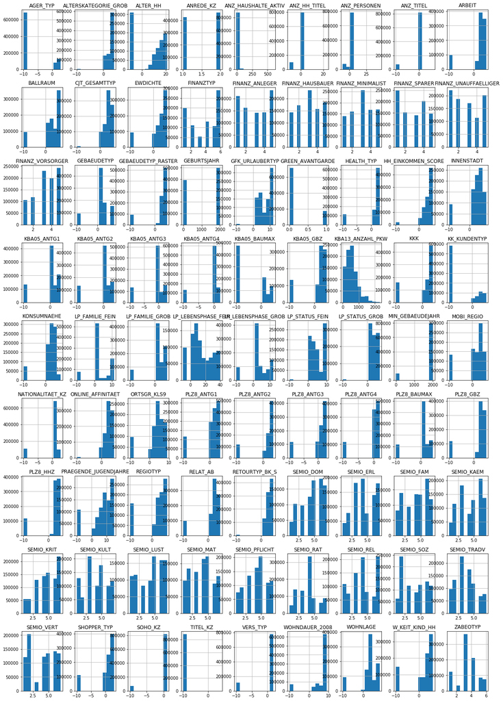

```python
# Perform an assessment of how much missing data there is in each column of the
# dataset.
# Replace np.nan to -10 to emphasize them
df.replace(np.nan, -10).hist(figsize=(20,30))
```

```python
def get_columns_above_na_threshold(df, threshold):
    num_rows = df.shape[0]
    na_ratios = df.isna().sum() / num_rows
    na_ratios_mask = na_ratios > threshold

    columns_to_be_removed = []
    for (index, value) in enumerate(na_ratios_mask):
        if value == True:
            name = na_ratios.keys()[index]
            columns_to_be_removed.append(name)
    return columns_to_be_removed
```

```python
# Get attributes when NaN values represents more than 20%
columns_to_be_removed = get_columns_above_na_threshold(df, 0.2)
columns_to_be_removed
```

```
['AGER_TYP',
 'GEBURTSJAHR',
 'TITEL_KZ',
 'ALTER_HH',
 'KK_KUNDENTYP',
 'KBA05_BAUMAX']
```

These columns will be removed.

```python
df.apply(pd.Series.value_counts)
```

[output not shown]

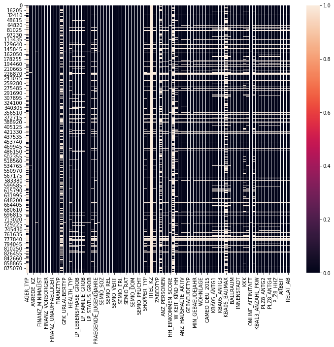

```python
width = 12
height = 10
plt.figure(figsize=(width, height))
sns.heatmap(df.isnull())
```

```python
# Investigate patterns in the amount of missing data in each column.

# Print the new shape after removing the columns having more than 20% of NaN values
df.drop(columns_to_be_removed, axis=1).shape
```

```
(891221, 79)
```

```python
# Remove the outlier columns from the dataset. (You'll perform other data
# engineering tasks such as re-encoding and imputation later.)
```

#### Discussion 1.1.2: Assess Missing Data in Each Column

(Double click this cell and replace this text with your own text, reporting your observations regarding the amount of missing data in each column. Are there any patterns in missing values? Which columns were removed from the dataset?)

The graph above emphasizes the columns we are gonna to delete: ['AGER_TYP', 'GEBURTSJAHR', 'TITEL_KZ', 'ALTER_HH', 'KK_KUNDENTYP', 'KBA05_BAUMAX']

These columns have more than 20% missing values. But it also shows that many rows has a lot of missing values. We should also delete these rows. But we will see that in the next section.

#### Step 1.1.3: Assess Missing Data in Each Row

Now, you'll perform a similar assessment for the rows of the dataset. How much data is missing in each row? As with the columns, you should see some groups of points that have a very different numbers of missing values. Divide the data into two subsets: one for data points that are above some threshold for missing values, and a second subset for points below that threshold.

In order to know what to do with the outlier rows, we should see if the distribution of data values on columns that are not missing data (or are missing very little data) are similar or different between the two groups. Select at least five of these columns and compare the distribution of values.

- You can use seaborn's [`countplot()`](https://seaborn.pydata.org/generated/seaborn.countplot.html) function to create a bar chart of code frequencies and matplotlib's [`subplot()`](https://matplotlib.org/api/_as_gen/matplotlib.pyplot.subplot.html) function to put bar charts for the two subplots side by side.
- To reduce repeated code, you might want to write a function that can perform this comparison, taking as one of its arguments a column to be compared.

Depending on what you observe in your comparison, this will have implications on how you approach your conclusions later in the analysis. If the distributions of non-missing features look similar between the data with many missing values and the data with few or no missing values, then we could argue that simply dropping those points from the analysis won't present a major issue. On the other hand, if the data with many missing values looks very different from the data with few or no missing values, then we should make a note on those data as special. We'll revisit these data later on. **Either way, you should continue your analysis for now using just the subset of the data with few or no missing values.**

```python
# How much data is missing in each row of the dataset?
df_na_row = df.isnull().sum(axis=1)
```

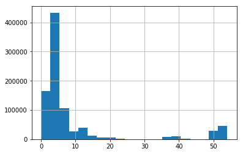

```python
# Graph: Count rows which have x null values.
df_na_row.hist(bins=20)
```

```python
def remove_rows_above_na_threshold(df, threshold):
    mask = df.isnull().sum(axis=1) > threshold
    df_no_na_rows = df.drop(df[mask].index)
    return df_no_na_rows
```

```
# rows found with  10 % null values:  159097
Shape after deleting these rows:  (732124, 85)
```

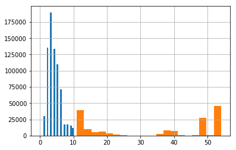

```python
# Write code to divide the data into two subsets based on the number of missing
# values in each row.
# Set a % threshold to separate rows
threshold = 10
mask = df.isnull().sum(axis=1) > threshold
print("# rows found with ", threshold,"% null values: ",mask.sum())
df_no_na_rows = remove_rows_above_na_threshold(df, threshold)
#df.drop(df[mask].index)
df_with_na_rows = df.drop(df[~mask].index)

print("Shape after deleting these rows: ", df_no_na_rows.shape)

# Plot the data to check if is works
df_no_na_rows.isnull().sum(axis=1).hist(bins=20)
df_with_na_rows.isnull().sum(axis=1).hist(bins=20)
```

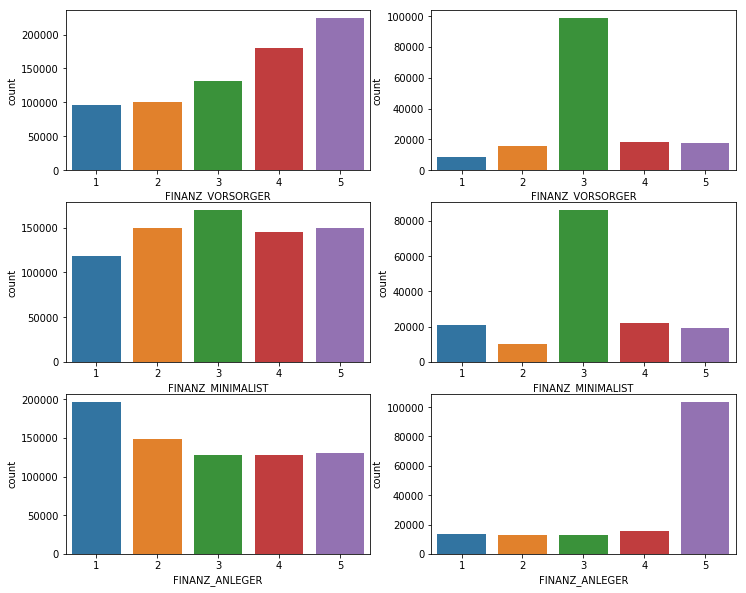

```python
# Compare the distribution of values for at least five columns where there are
# no or few missing values, between the two subsets.
width = 12
height = 10
plt.figure(figsize=(width, height))


def plot_countplots(columns):
    nb_columns = len(columns)
    for (index, column) in enumerate(columns):
        ax1 = plt.subplot(nb_columns,2,index*2+1)
        sns.countplot(df_no_na_rows[column], ax = ax1)

        ax2 = plt.subplot(nb_columns,2,index*2+2)
        sns.countplot(df_with_na_rows[column], ax = ax2)

columns = ["FINANZ_VORSORGER", "FINANZ_MINIMALIST", "FINANZ_ANLEGER"]
plot_countplots(columns)
```

#### Discussion 1.1.3: Assess Missing Data in Each Row

(Double-click this cell and replace this text with your own text, reporting your observations regarding missing data in rows. Are the data with lots of missing values are qualitatively different from data with few or no missing values?)

By comparing distribution between datasets that contain or not rows with more than 10% null values, we can note the following:

- in the "clean" dataset, the distribution looks quite homogenous
- in the "dirty" dataset, the distribution is very different. There is one leading value. The others are much less represented. A strategy could be to fill the rows with null values with this leading value.

### Step 1.2: Select and Re-Encode Features

Checking for missing data isn't the only way in which you can prepare a dataset for analysis. Since the unsupervised learning techniques to be used will only work on data that is encoded numerically, you need to make a few encoding changes or additional assumptions to be able to make progress. In addition, while almost all of the values in the dataset are encoded using numbers, not all of them represent numeric values. Check the third column of the feature summary (`feat_info`) for a summary of types of measurement.

- For numeric and interval data, these features can be kept without changes.
- Most of the variables in the dataset are ordinal in nature. While ordinal values may technically be non-linear in spacing, make the simplifying assumption that the ordinal variables can be treated as being interval in nature (that is, kept without any changes).
- Special handling may be necessary for the remaining two variable types: categorical, and 'mixed'.

In the first two parts of this sub-step, you will perform an investigation of the categorical and mixed-type features and make a decision on each of them, whether you will keep, drop, or re-encode each. Then, in the last part, you will create a new data frame with only the selected and engineered columns.

Data wrangling is often the trickiest part of the data analysis process, and there's a lot of it to be done here. But stick with it: once you're done with this step, you'll be ready to get to the machine learning parts of the project!

```
ordinal        49
categorical    21
numeric         7
mixed           7
interval        1
Name: type, dtype: int64
```

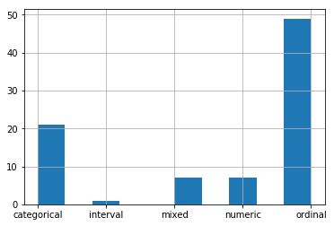

```python
# How many features are there of each data type?
feat_info.groupby("type").count()
print(feat_info["type"].value_counts())
feat_info["type"].hist()
```

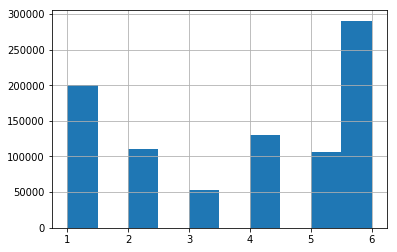

```python
# Get categorical columns
column = "FINANZTYP"
df[column].hist()
```

```python
categorical_columns = feat_info[feat_info["type"]=="categorical"]["attribute"].values
mixed_columns = feat_info[feat_info["type"]=="mixed"]["attribute"].values

print("# Categorical columns: ", len(categorical_columns))
print("# Mixed columns: ", len(mixed_columns))
```

```
# Categorical columns:  21
# Mixed columns:  7
```

```python
def plot_columns_distribution(columns, nb_cols=4):
    nb_columns = len(columns)

    for (index, column) in enumerate(columns):
        ax1 = plt.subplot(nb_columns,nb_cols,index+1)
        sns.countplot(df[column], ax = ax1)
    plt.tight_layout()
```

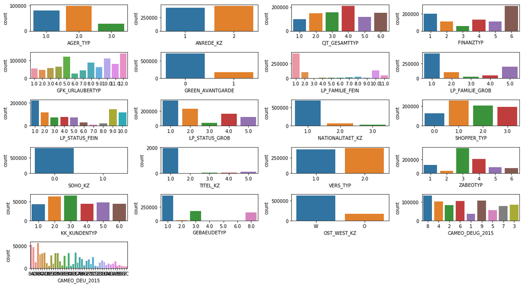

```python
width = 16
height = 30
plt.figure(figsize=(width, height))

plot_columns_distribution(categorical_columns)
```

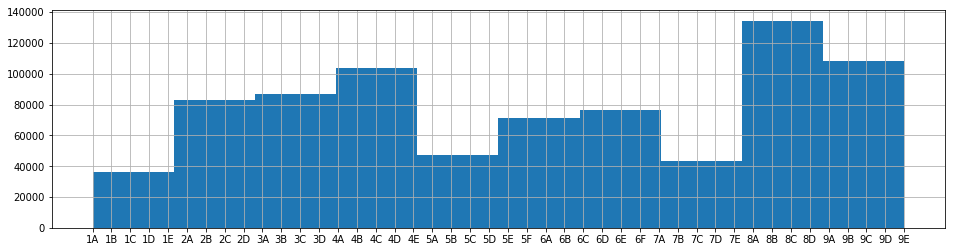

```python
# Plot CAMEO_DEU_2015 as it can not be seen properly above
width = 16
height = 4
plt.figure(figsize=(width, height))
df["CAMEO_DEU_2015"].hist()
```

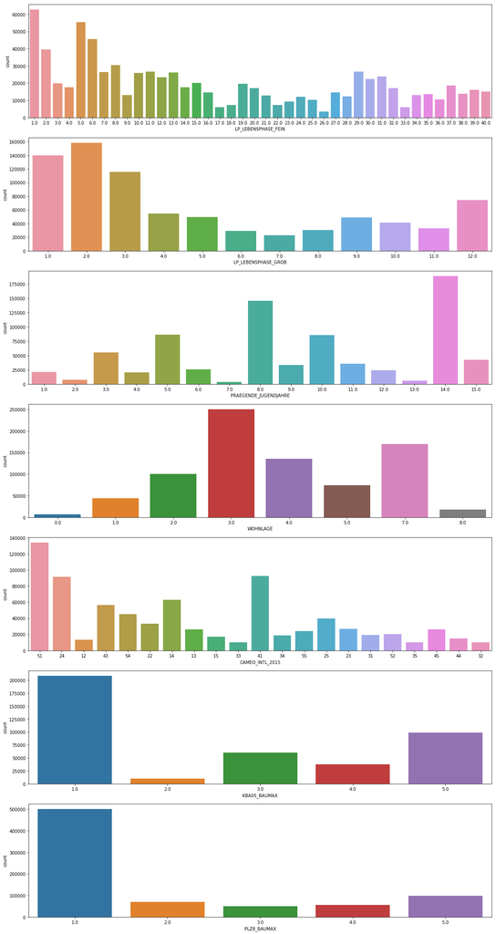

```python
width = 16
height = 30
plt.figure(figsize=(width, height))

plot_columns_distribution(mixed_columns, nb_cols=1)
```

#### Step 1.2.1: Re-Encode Categorical Features

For categorical data, you would ordinarily need to encode the levels as dummy variables. Depending on the number of categories, perform one of the following:

- For binary (two-level) categoricals that take numeric values, you can keep them without needing to do anything.
- There is one binary variable that takes on non-numeric values. For this one, you need to re-encode the values as numbers or create a dummy variable.
- For multi-level categoricals (three or more values), you can choose to encode the values using multiple dummy variables (e.g. via [OneHotEncoder](http://scikit-learn.org/stable/modules/generated/sklearn.preprocessing.OneHotEncoder.html)), or (to keep things straightforward) just drop them from the analysis. As always, document your choices in the Discussion section.

```python
# Assess categorical variables: which are binary, which are multi-level, and
# which one needs to be re-encoded?

# Print the different values present in each columns to see which one will be re-encoded
for column in categorical_columns:
    print(column, df[column].dropna().unique())
```

```
AGER_TYP [ 2.  3.  1.]
ANREDE_KZ [1 2]
CJT_GESAMTTYP [ 2.  5.  3.  4.  1.  6.]
FINANZTYP [4 1 6 5 2 3]
GFK_URLAUBERTYP [ 10.   1.   5.  12.   9.   3.   8.  11.   4.   2.   7.   6.]
GREEN_AVANTGARDE [0 1]
LP_FAMILIE_FEIN [  2.   5.   1.  10.   7.  11.   3.   8.   4.   6.   9.]
LP_FAMILIE_GROB [ 2.  3.  1.  5.  4.]
LP_STATUS_FEIN [  1.   2.   3.   9.   4.  10.   5.   8.   6.   7.]
LP_STATUS_GROB [ 1.  2.  4.  5.  3.]
NATIONALITAET_KZ [ 1.  3.  2.]
SHOPPER_TYP [ 3.  2.  1.  0.]
SOHO_KZ [ 1.  0.]
TITEL_KZ [ 4.  1.  3.  5.  2.]
VERS_TYP [ 2.  1.]
ZABEOTYP [3 5 4 1 6 2]
KK_KUNDENTYP [ 1.  3.  6.  4.  2.  5.]
GEBAEUDETYP [ 8.  1.  3.  2.  6.  4.  5.]
OST_WEST_KZ ['W' 'O']
CAMEO_DEUG_2015 ['8' '4' '2' '6' '1' '9' '5' '7' '3']
CAMEO_DEU_2015 ['8A' '4C' '2A' '6B' '8C' '4A' '2D' '1A' '1E' '9D' '5C' '8B' '7A' '5D' '9E'
 '9B' '1B' '3D' '4E' '4B' '3C' '5A' '7B' '9A' '6D' '6E' '2C' '7C' '9C' '7D'
 '5E' '1D' '8D' '6C' '6A' '5B' '4D' '3A' '2B' '7E' '3B' '6F' '5F' '1C']
```

## Columns to re-encode

Base on what we have just seen, these columns must be re-encoded/

- CAMEO_DEU_2015: values like "8A", "4D",..
- OST_WEST__KZ: ["W", "O"]
- CAMEO_DEUG_2015: must be parse to integer as its values are strings

```python
# Re-encode OST_WEST_KZ ['W' 'O']
column = "OST_WEST_KZ"
df[column].map({"W":1, "O":0}).head()
```

```
0    NaN
1    1.0
2    1.0
3    1.0
4    1.0
Name: OST_WEST_KZ, dtype: float64
```

```python
# Re-encode
# CAMEO_DEUG_2015
from sklearn.preprocessing import OneHotEncoder
encoder = OneHotEncoder(sparse=False)
column="CAMEO_DEUG_2015"

pd.get_dummies(df[column].dropna(), prefix=column).head()
```

|  | CAMEO_DEUG_2015_1 | CAMEO_DEUG_2015_2 | CAMEO_DEUG_2015_3 | CAMEO_DEUG_2015_4 | CAMEO_DEUG_2015_5 | CAMEO_DEUG_2015_6 | CAMEO_DEUG_2015_7 | CAMEO_DEUG_2015_8 | CAMEO_DEUG_2015_9 |
| --- | --- | --- | --- | --- | --- | --- | --- | --- | --- |
| 1 | 0 | 0 | 0 | 0 | 0 | 0 | 0 | 1 | 0 |
| 2 | 0 | 0 | 0 | 1 | 0 | 0 | 0 | 0 | 0 |
| 3 | 0 | 1 | 0 | 0 | 0 | 0 | 0 | 0 | 0 |
| 4 | 0 | 0 | 0 | 0 | 0 | 1 | 0 | 0 | 0 |
| 5 | 0 | 0 | 0 | 0 | 0 | 0 | 0 | 1 | 0 |

```python
# Re-encode
# CAMEO_DEU_2015
column="CAMEO_DEU_2015"
pd.get_dummies(df[column].dropna(), prefix=column).head()
```

|  | CAMEO_DEU_2015_1A | CAMEO_DEU_2015_1B | CAMEO_DEU_2015_1C | CAMEO_DEU_2015_1D | CAMEO_DEU_2015_1E | CAMEO_DEU_2015_2A | CAMEO_DEU_2015_2B | CAMEO_DEU_2015_2C | CAMEO_DEU_2015_2D | CAMEO_DEU_2015_3A | ... | CAMEO_DEU_2015_7E | CAMEO_DEU_2015_8A | CAMEO_DEU_2015_8B | CAMEO_DEU_2015_8C | CAMEO_DEU_2015_8D | CAMEO_DEU_2015_9A | CAMEO_DEU_2015_9B | CAMEO_DEU_2015_9C | CAMEO_DEU_2015_9D | CAMEO_DEU_2015_9E |
| --- | --- | --- | --- | --- | --- | --- | --- | --- | --- | --- | --- | --- | --- | --- | --- | --- | --- | --- | --- | --- | --- |
| 1 | 0 | 0 | 0 | 0 | 0 | 0 | 0 | 0 | 0 | 0 | ... | 0 | 1 | 0 | 0 | 0 | 0 | 0 | 0 | 0 | 0 |
| 2 | 0 | 0 | 0 | 0 | 0 | 0 | 0 | 0 | 0 | 0 | ... | 0 | 0 | 0 | 0 | 0 | 0 | 0 | 0 | 0 | 0 |
| 3 | 0 | 0 | 0 | 0 | 0 | 1 | 0 | 0 | 0 | 0 | ... | 0 | 0 | 0 | 0 | 0 | 0 | 0 | 0 | 0 | 0 |
| 4 | 0 | 0 | 0 | 0 | 0 | 0 | 0 | 0 | 0 | 0 | ... | 0 | 0 | 0 | 0 | 0 | 0 | 0 | 0 | 0 | 0 |
| 5 | 0 | 0 | 0 | 0 | 0 | 0 | 0 | 0 | 0 | 0 | ... | 0 | 0 | 0 | 1 | 0 | 0 | 0 | 0 | 0 | 0 |

5 rows × 44 columns

##### Re-encode categorical variable(s) to be kept in the analysis.

#### Discussion 1.2.1: Re-Encode Categorical Features

(Double-click this cell and replace this text with your own text, reporting your findings and decisions regarding categorical features. Which ones did you keep, which did you drop, and what engineering steps did you perform?)

- CAMEO_DEU_2015: values like "8A", "4D",..
- OST_WEST__KZ: ["W", "O"]
- CAMEO_DEUG_2015: must be parse to integer as its values are strings

At the moment, we will keep them all. We re-econded them.

In a further exploration, we should explore what their impact is. In fact, re-encoding them generates a lot of new features, and it may add noise and be counter productive.

#### Step 1.2.2: Engineer Mixed-Type Features

There are a handful of features that are marked as "mixed" in the feature summary that require special treatment in order to be included in the analysis. There are two in particular that deserve attention; the handling of the rest are up to your own choices:

- "PRAEGENDE_JUGENDJAHRE" combines information on three dimensions: generation by decade, movement (mainstream vs. avantgarde), and nation (east vs. west). While there aren't enough levels to disentangle east from west, you should create two new variables to capture the other two dimensions: an interval-type variable for decade, and a binary variable for movement.
- "CAMEO_INTL_2015" combines information on two axes: wealth and life stage. Break up the two-digit codes by their 'tens'-place and 'ones'-place digits into two new ordinal variables (which, for the purposes of this project, is equivalent to just treating them as their raw numeric values).
- If you decide to keep or engineer new features around the other mixed-type features, make sure you note your steps in the Discussion section.

Be sure to check `Data_Dictionary.md` for the details needed to finish these tasks.

```python
print("Mixed: ")
for column in mixed_columns:
    print(column, df[column].dropna().unique())
```

```
Mixed:
LP_LEBENSPHASE_FEIN [ 15.  21.   3.  32.   8.   2.   5.  10.   4.   6.  23.  12.  20.   1.  11.
  25.  13.   7.  18.  31.  19.  38.  35.  30.  22.  14.  33.  29.  24.  28.
  37.  26.  39.  27.  36.   9.  34.  40.  16.  17.]
LP_LEBENSPHASE_GROB [  4.   6.   1.  10.   2.   3.   5.   7.  12.  11.   9.   8.]
PRAEGENDE_JUGENDJAHRE [ 14.  15.   8.   3.  10.  11.   5.   9.   6.   4.   2.   1.  12.  13.   7.]
WOHNLAGE [ 4.  2.  7.  3.  5.  1.  8.  0.]
CAMEO_INTL_2015 ['51' '24' '12' '43' '54' '22' '14' '13' '15' '33' '41' '34' '55' '25' '23'
 '31' '52' '35' '45' '44' '32']
KBA05_BAUMAX [ 5.  1.  2.  3.  4.]
PLZ8_BAUMAX [ 1.  2.  4.  5.  3.]
```

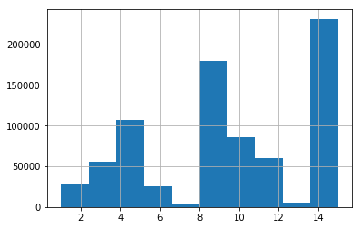

```python
# Investigate "PRAEGENDE_JUGENDJAHRE" and engineer two new variables.
column = "PRAEGENDE_JUGENDJAHRE"
df[column].hist()
```

According to Data_Dictionary.md

```
### 1.18. PRAEGENDE_JUGENDJAHRE
Dominating movement of person's youth (avantgarde vs. mainstream; east vs. west)
- -1: unknown
-  0: unknown
-  1: 40s - war years (Mainstream, E+W)
-  2: 40s - reconstruction years (Avantgarde, E+W)
-  3: 50s - economic miracle (Mainstream, E+W)
-  4: 50s - milk bar / Individualisation (Avantgarde, E+W)
-  5: 60s - economic miracle (Mainstream, E+W)
-  6: 60s - generation 68 / student protestors (Avantgarde, W)
-  7: 60s - opponents to the building of the Wall (Avantgarde, E)
-  8: 70s - family orientation (Mainstream, E+W)
-  9: 70s - peace movement (Avantgarde, E+W)
- 10: 80s - Generation Golf (Mainstream, W)
- 11: 80s - ecological awareness (Avantgarde, W)
- 12: 80s - FDJ / communist party youth organisation (Mainstream, E)
- 13: 80s - Swords into ploughshares (Avantgarde, E)
- 14: 90s - digital media kids (Mainstream, E+W)
- 15: 90s - ecological awareness (Avantgarde, E+W)
```

```python
# Set dictionary with corresponding values
movement_dict = {
     1:1, 2:0, 3:1, 4:0, 5:1, 6:0, 7:0, 8:1, 9:0, 10:1, 11:0, 12:1, 13:0, 14:1, 15:0
}
decades_dict = { 1:40, 2:40, 3:50, 4:50, 5:60, 6:60, 7:60, 8:70, 9:70, 10:80, 11:80, 12:80, 13:80, 14:90, 15:90}

def process_categorical_column(df, column, dictionary):
    return df[column].map(dictionary)

column = "PRAEGENDE_JUGENDJAHRE"
print(df[column].head(10))
# Print to check movement
movement = process_categorical_column(df,column,movement_dict)
movement.head(10)
```

```
0     NaN
1    14.0
2    15.0
3     8.0
4     8.0
5     3.0
6    10.0
7     8.0
8    11.0
9    15.0
Name: PRAEGENDE_JUGENDJAHRE, dtype: float64
```

```
0    NaN
1    1.0
2    0.0
3    1.0
4    1.0
5    1.0
6    1.0
7    1.0
8    0.0
9    0.0
Name: PRAEGENDE_JUGENDJAHRE, dtype: float64
```

```python
# Print to check decades
column = "PRAEGENDE_JUGENDJAHRE"
decades = process_categorical_column(df,column,decades_dict)
decades.head(10)
```

```
0     NaN
1    90.0
2    90.0
3    70.0
4    70.0
5    50.0
6    80.0
7    70.0
8    80.0
9    90.0
Name: PRAEGENDE_JUGENDJAHRE, dtype: float64
```

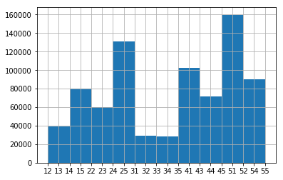

```python
# Investigate "CAMEO_INTL_2015" and engineer two new variables.
column = "CAMEO_INTL_2015"
df[column].hist()
```

According to Data_Dictionary.md

```
### 4.3. CAMEO_INTL_2015
German CAMEO: Wealth / Life Stage Typology, mapped to international code
- -1: unknown
- 11: Wealthy Households - Pre-Family Couples & Singles
- 12: Wealthy Households - Young Couples With Children
- 13: Wealthy Households - Families With School Age Children
- 14: Wealthy Households - Older Families &  Mature Couples
- 15: Wealthy Households - Elders In Retirement
- 21: Prosperous Households - Pre-Family Couples & Singles
- 22: Prosperous Households - Young Couples With Children
- 23: Prosperous Households - Families With School Age Children
- 24: Prosperous Households - Older Families & Mature Couples
- 25: Prosperous Households - Elders In Retirement
- 31: Comfortable Households - Pre-Family Couples & Singles
- 32: Comfortable Households - Young Couples With Children
- 33: Comfortable Households - Families With School Age Children
- 34: Comfortable Households - Older Families & Mature Couples
- 35: Comfortable Households - Elders In Retirement
- 41: Less Affluent Households - Pre-Family Couples & Singles
- 42: Less Affluent Households - Young Couples With Children
- 43: Less Affluent Households - Families With School Age Children
- 44: Less Affluent Households - Older Families & Mature Couples
- 45: Less Affluent Households - Elders In Retirement
- 51: Poorer Households - Pre-Family Couples & Singles
- 52: Poorer Households - Young Couples With Children
- 53: Poorer Households - Families With School Age Children
- 54: Poorer Households - Older Families & Mature Couples
- 55: Poorer Households - Elders In Retirement
- XX: unknown
```

I will decompose this way:

### Wealth

- Wealthy Households: 1
- Prosperous Households: 2
- Comfortable Households: 3
- Less Affluent Households: 4
- Poorer Households: 5
- unknown: 0

### Life stage

- Pre-Family Couples & Singles: 1
- Young Couples With Children: 2
- Families With School Age Children: 3
- Older Families & Mature Couples: 4
- Elders In Retirement: 5
- unknown: 0

```python
column = "CAMEO_INTL_2015"

def process_wealth_serie(df):
    column = "CAMEO_INTL_2015"
    return df[column].map(lambda x: int(str(x)[0]) if not pd.isna(x) else np.nan)

def process_life_stage_serie(df):
    column = "CAMEO_INTL_2015"
    return df[column].map(lambda x: int(str(x)[1]) if not pd.isna(x) else np.nan)

wealth = process_wealth_serie(df)
life_stage = process_life_stage_serie(df)
```

```python
df[column].head(20)
```

```
0     NaN
1      51
2      24
3      12
4      43
5      54
6      22
7      14
8      13
9      15
10     51
11    NaN
12     43
13     33
14    NaN
15     41
16     41
17    NaN
18     24
19     34
Name: CAMEO_INTL_2015, dtype: object
```

```python
wealth.head(20)
```

```
0     NaN
1     5.0
2     2.0
3     1.0
4     4.0
5     5.0
6     2.0
7     1.0
8     1.0
9     1.0
10    5.0
11    NaN
12    4.0
13    3.0
14    NaN
15    4.0
16    4.0
17    NaN
18    2.0
19    3.0
Name: CAMEO_INTL_2015, dtype: float64
```

```python
life_stage.head(20)
```

```
0     NaN
1     1.0
2     4.0
3     2.0
4     3.0
5     4.0
6     2.0
7     4.0
8     3.0
9     5.0
10    1.0
11    NaN
12    3.0
13    3.0
14    NaN
15    1.0
16    1.0
17    NaN
18    4.0
19    4.0
Name: CAMEO_INTL_2015, dtype: float64
```

#### Discussion 1.2.2: Engineer Mixed-Type Features

(Double-click this cell and replace this text with your own text, reporting your findings and decisions regarding mixed-value features. Which ones did you keep, which did you drop, and what engineering steps did you perform?)

- CAMEO_INTL_2015
- PRAEGENDE_JUGENDJAHRE

For each mix-type feature, we re-encoded the values and get 4 new features:

- Decades and Movement from `PRAEGENDE_JUGENDJAHRE`
- Wealth and Life stage from `CAMEO_INTL_2015`

I keep the features that I generated.

#### Step 1.2.3: Complete Feature Selection

In order to finish this step up, you need to make sure that your data frame now only has the columns that you want to keep. To summarize, the dataframe should consist of the following:

- All numeric, interval, and ordinal type columns from the original dataset.
- Binary categorical features (all numerically-encoded).
- Engineered features from other multi-level categorical features and mixed features.

Make sure that for any new columns that you have engineered, that you've excluded the original columns from the final dataset. Otherwise, their values will interfere with the analysis later on the project. For example, you should not keep "PRAEGENDE_JUGENDJAHRE", since its values won't be useful for the algorithm: only the values derived from it in the engineered features you created should be retained. As a reminder, your data should only be from **the subset with few or no missing values**.

```python
# If there are other re-engineering tasks you need to perform, make sure you
# take care of them here. (Dealing with missing data will come in step 2.1.)

# ==> Nothing more to add. Everything will be done into the clean_data function.
```

```python
# Do whatever you need to in order to ensure that the dataframe only contains
# the columns that should be passed to the algorithm functions.
```

### Step 1.3: Create a Cleaning Function

Even though you've finished cleaning up the general population demographics data, it's important to look ahead to the future and realize that you'll need to perform the same cleaning steps on the customer demographics data. In this substep, complete the function below to execute the main feature selection, encoding, and re-engineering steps you performed above. Then, when it comes to looking at the customer data in Step 3, you can just run this function on that DataFrame to get the trimmed dataset in a single step.

```python
def clean_data(df):
    """
    Perform feature trimming, re-encoding, and engineering for demographics
    data

    INPUT: Demographics DataFrame
    OUTPUT: Trimmed and cleaned demographics DataFrame
    """

    # Put in code here to execute all main cleaning steps:
    # convert missing value codes into NaNs, ...
    print(df.shape)

    # Step 1.1.1: Convert Missing Value Codes to NaNs
    print("Step 1.1.1: Convert Missing Value Codes to NaNs")
    for i in df.columns:
        df = replace_missing(df,i)
    print(df.shape)


    # remove selected columns and rows, ...
    # Step 1.1.2: Assess Missing Data in Each Column
    print("Step 1.1.2: Assess Missing Data in Each Column")
    threshold = 0.5
    columns_to_drop = get_columns_above_na_threshold(df, threshold)
    df = df.drop(columns=columns_to_drop)
    print(df.shape)

    # Step 1.1.3: Assess Missing Data in Each Row
    print("Step 1.1.3: Assess Missing Data in Each Row")
    threshold = 10
    df = remove_rows_above_na_threshold(df, threshold)
    print(df.shape)

    # select, re-encode, and engineer column values.
    # Step 1.2.1: Re-Encode Categorical Features
    print("Step 1.2.1: Re-Encode Categorical Features")

    column = "OST_WEST_KZ"
    if column in df.columns:
        df[column] = df[column].map({"W":1, "O":0})
    else:
        print(column, " is not present.")

    column="CAMEO_DEUG_2015"
    if column in df.columns:
        dummies = pd.get_dummies(df[column].dropna(), prefix=column)
        df = pd.concat([df, dummies], axis=1)
        df = df.drop(columns=[column])
    else:
        print(column, " is not present.")
    print(df.shape)

    column="CAMEO_DEU_2015"
    if column in df.columns:
        dummies = pd.get_dummies(df[column].dropna(), prefix=column)
        df = pd.concat([df, dummies], axis=1)
        df = df.drop(columns=[column])
    else:
        print(column, " is not present.")
    print(df.shape)

    # Step 1.2.2: Engineer Mixed-Type Features
    print("Step 1.2.2: Engineer Mixed-Type Features")

    column = "PRAEGENDE_JUGENDJAHRE"
    movement_dict = {
     1:1, 2:0, 3:1, 4:0, 5:1, 6:0, 7:0, 8:1, 9:0, 10:1, 11:0, 12:1, 13:0, 14:1, 15:0
    }
    decades_dict = { 1:40, 2:40, 3:50, 4:50, 5:60, 6:60, 7:60, 8:70, 9:70, 10:80, 11:80, 12:80, 13:80, 14:90, 15:90}
    if column in df.columns:
        movement = process_categorical_column(df, column, movement_dict)
        decades = process_categorical_column(df, column, decades_dict)

        df["PRAEGENDE_JUGENDJAHRE_MOVEMENT"] = movement
        df["PRAEGENDE_JUGENDJAHRE_DECADES"] = decades
        df = df.drop(columns=[column])
    else:
        print(column, " is not present.")

    print(df.shape)

    column = "CAMEO_INTL_2015"
    if column in df.columns:
        wealth = process_wealth_serie(df)
        life_stage = process_life_stage_serie(df)

        df["CAMEO_INTL_2015_WEALTH"] = wealth
        df["CAMEO_INTL_2015_LIFE_STAGE"] = life_stage
        df = df.drop(columns=[column])
    else:
        print(column, " is not present.")

    # Return the cleaned dataframe.
    return df
```

```python
df_clean = clean_data(azdias)
```

```
(891221, 85)
Step 1.1.1: Convert Missing Value Codes to NaNs
(891221, 85)
Step 1.1.2: Assess Missing Data in Each Column
(891221, 81)
Step 1.1.3: Assess Missing Data in Each Row
(776422, 81)
Step 1.2.1: Re-Encode Categorical Features
(776422, 89)
(776422, 132)
Step 1.2.2: Engineer Mixed-Type Features
(776422, 133)
```

```python
print("Shape: ",df_clean.shape)
df_clean.describe()
```

```
Shape:  (776422, 134)
```

|  | ALTERSKATEGORIE_GROB | ANREDE_KZ | CJT_GESAMTTYP | FINANZ_MINIMALIST | FINANZ_SPARER | FINANZ_VORSORGER | FINANZ_ANLEGER | FINANZ_UNAUFFAELLIGER | FINANZ_HAUSBAUER | FINANZTYP | ... | CAMEO_DEU_2015_8D | CAMEO_DEU_2015_9A | CAMEO_DEU_2015_9B | CAMEO_DEU_2015_9C | CAMEO_DEU_2015_9D | CAMEO_DEU_2015_9E | PRAEGENDE_JUGENDJAHRE_MOVEMENT | PRAEGENDE_JUGENDJAHRE_DECADES | CAMEO_INTL_2015_WEALTH | CAMEO_INTL_2015_LIFE_STAGE |
| --- | --- | --- | --- | --- | --- | --- | --- | --- | --- | --- | --- | --- | --- | --- | --- | --- | --- | --- | --- | --- | --- |
| count | 773859.000000 | 776422.000000 | 773909.000000 | 776422.000000 | 776422.000000 | 776422.000000 | 776422.000000 | 776422.000000 | 776422.000000 | 776422.000000 | ... | 772948.000000 | 772948.000000 | 772948.000000 | 772948.000000 | 772948.000000 | 772948.000000 | 751774.000000 | 751774.000000 | 772948.000000 | 772948.000000 |
| mean | 2.795878 | 1.521039 | 3.497268 | 3.051280 | 2.711399 | 3.438115 | 2.837734 | 2.632747 | 3.142663 | 3.820653 | ... | 0.022472 | 0.026248 | 0.035481 | 0.032063 | 0.036569 | 0.007760 | 0.772227 | 73.248210 | 3.274449 | 2.870147 |
| std | 1.019502 | 0.499557 | 1.535971 | 1.377443 | 1.485816 | 1.377171 | 1.471961 | 1.393429 | 1.398383 | 2.089770 | ... | 0.148214 | 0.159871 | 0.184992 | 0.176167 | 0.187701 | 0.087748 | 0.419396 | 14.583226 | 1.465529 | 1.487863 |
| min | 1.000000 | 1.000000 | 1.000000 | 1.000000 | 1.000000 | 1.000000 | 1.000000 | 1.000000 | 1.000000 | 1.000000 | ... | 0.000000 | 0.000000 | 0.000000 | 0.000000 | 0.000000 | 0.000000 | 0.000000 | 40.000000 | 1.000000 | 1.000000 |
| 25% | 2.000000 | 1.000000 | 2.000000 | 2.000000 | 1.000000 | 2.000000 | 1.000000 | 1.000000 | 2.000000 | 2.000000 | ... | 0.000000 | 0.000000 | 0.000000 | 0.000000 | 0.000000 | 0.000000 | 1.000000 | 60.000000 | 2.000000 | 1.000000 |
| 50% | 3.000000 | 2.000000 | 4.000000 | 3.000000 | 3.000000 | 4.000000 | 3.000000 | 2.000000 | 3.000000 | 5.000000 | ... | 0.000000 | 0.000000 | 0.000000 | 0.000000 | 0.000000 | 0.000000 | 1.000000 | 70.000000 | 4.000000 | 3.000000 |
| 75% | 4.000000 | 2.000000 | 5.000000 | 4.000000 | 4.000000 | 5.000000 | 4.000000 | 4.000000 | 4.000000 | 6.000000 | ... | 0.000000 | 0.000000 | 0.000000 | 0.000000 | 0.000000 | 0.000000 | 1.000000 | 90.000000 | 5.000000 | 4.000000 |
| max | 4.000000 | 2.000000 | 6.000000 | 5.000000 | 5.000000 | 5.000000 | 5.000000 | 5.000000 | 5.000000 | 6.000000 | ... | 1.000000 | 1.000000 | 1.000000 | 1.000000 | 1.000000 | 1.000000 | 1.000000 | 90.000000 | 5.000000 | 5.000000 |

8 rows × 134 columns

```python
df_clean.info()
```

```
<class 'pandas.core.frame.DataFrame'>
Int64Index: 776422 entries, 1 to 891220
Columns: 134 entries, ALTERSKATEGORIE_GROB to CAMEO_INTL_2015_LIFE_STAGE
dtypes: float64(109), int64(25)
memory usage: 799.7 MB
```

## Step 2: Feature Transformation

### Step 2.1: Apply Feature Scaling

Before we apply dimensionality reduction techniques to the data, we need to perform feature scaling so that the principal component vectors are not influenced by the natural differences in scale for features. Starting from this part of the project, you'll want to keep an eye on the [API reference page for sklearn](http://scikit-learn.org/stable/modules/classes.html) to help you navigate to all of the classes and functions that you'll need. In this substep, you'll need to check the following:

- sklearn requires that data not have missing values in order for its estimators to work properly. So, before applying the scaler to your data, make sure that you've cleaned the DataFrame of the remaining missing values. This can be as simple as just removing all data points with missing data, or applying an [Imputer](http://scikit-learn.org/stable/modules/generated/sklearn.preprocessing.Imputer.html) to replace all missing values. You might also try a more complicated procedure where you temporarily remove missing values in order to compute the scaling parameters before re-introducing those missing values and applying imputation. Think about how much missing data you have and what possible effects each approach might have on your analysis, and justify your decision in the discussion section below.
- For the actual scaling function, a [StandardScaler](http://scikit-learn.org/stable/modules/generated/sklearn.preprocessing.StandardScaler.html) instance is suggested, scaling each feature to mean 0 and standard deviation 1.
- For these classes, you can make use of the `.fit_transform()` method to both fit a procedure to the data as well as apply the transformation to the data at the same time. Don't forget to keep the fit sklearn objects handy, since you'll be applying them to the customer demographics data towards the end of the project.

```python
# Count number of Null values
df_clean.isnull().sum().sum()
```

```
1436849
```

```python
# If you've not yet cleaned the dataset of all NaN values, then investigate and
# do that now.

# This is the code to impute values. But as shown
# in the next cell, I prefer a this stage
# to remove all rows with NaN values before any
# further exploration.
from sklearn.preprocessing import Imputer
imputer = Imputer(strategy="most_frequent")
df_imputed = imputer.fit_transform(df_clean)
df_imputed = pd.DataFrame(df_imputed, columns= df_clean.columns)
```

```python
# Remove null
df_imputed = df_clean.dropna()

# Count number of Null values
df_imputed.isnull().sum().sum()
```

```
0
```

```python
# Apply feature scaling to the general population demographics data.
from sklearn.preprocessing import StandardScaler
scaler = StandardScaler()
scaled = scaler.fit_transform(df_imputed)
df_scaled = pd.DataFrame(scaled, columns= df_imputed.columns)

def scale_data(df):
    data_scaled = scaler.transform(df)
    data_scaled = pd.DataFrame(data_scaled, columns= df.columns)
    return data_scaled
```

```python
df_scaled.describe()
```

|  | ALTERSKATEGORIE_GROB | ANREDE_KZ | CJT_GESAMTTYP | FINANZ_MINIMALIST | FINANZ_SPARER | FINANZ_VORSORGER | FINANZ_ANLEGER | FINANZ_UNAUFFAELLIGER | FINANZ_HAUSBAUER | FINANZTYP | ... | CAMEO_DEU_2015_8D | CAMEO_DEU_2015_9A | CAMEO_DEU_2015_9B | CAMEO_DEU_2015_9C | CAMEO_DEU_2015_9D | CAMEO_DEU_2015_9E | PRAEGENDE_JUGENDJAHRE_MOVEMENT | PRAEGENDE_JUGENDJAHRE_DECADES | CAMEO_INTL_2015_WEALTH | CAMEO_INTL_2015_LIFE_STAGE |
| --- | --- | --- | --- | --- | --- | --- | --- | --- | --- | --- | --- | --- | --- | --- | --- | --- | --- | --- | --- | --- | --- |
| count | 3.481580e+05 | 3.481580e+05 | 3.481580e+05 | 3.481580e+05 | 3.481580e+05 | 3.481580e+05 | 3.481580e+05 | 3.481580e+05 | 3.481580e+05 | 3.481580e+05 | ... | 3.481580e+05 | 3.481580e+05 | 3.481580e+05 | 3.481580e+05 | 3.481580e+05 | 3.481580e+05 | 3.481580e+05 | 3.481580e+05 | 3.481580e+05 | 3.481580e+05 |
| mean | 1.820450e-16 | 3.677635e-17 | 1.249824e-16 | 4.742965e-17 | -5.730743e-17 | -5.481758e-17 | -5.310325e-17 | -1.706161e-17 | -4.885826e-17 | -1.183700e-17 | ... | -6.247081e-17 | 6.206264e-17 | -6.461372e-17 | 6.775665e-17 | -6.559333e-17 | -1.481666e-17 | 7.077712e-17 | -2.266174e-16 | -1.762285e-16 | -5.612373e-17 |
| std | 1.000001e+00 | 1.000001e+00 | 1.000001e+00 | 1.000001e+00 | 1.000001e+00 | 1.000001e+00 | 1.000001e+00 | 1.000001e+00 | 1.000001e+00 | 1.000001e+00 | ... | 1.000001e+00 | 1.000001e+00 | 1.000001e+00 | 1.000001e+00 | 1.000001e+00 | 1.000001e+00 | 1.000001e+00 | 1.000001e+00 | 1.000001e+00 | 1.000001e+00 |
| min | -1.727411e+00 | -1.031268e+00 | -1.716332e+00 | -1.531894e+00 | -1.178093e+00 | -1.665035e+00 | -1.270189e+00 | -1.163783e+00 | -1.520303e+00 | -1.414059e+00 | ... | -1.544038e-01 | -1.634099e-01 | -1.934174e-01 | -1.794695e-01 | -1.920869e-01 | -6.408506e-02 | -1.750602e+00 | -2.366012e+00 | -1.556048e+00 | -1.272792e+00 |
| 25% | -7.455682e-01 | -1.031268e+00 | -1.050275e+00 | -7.958570e-01 | -1.178093e+00 | -9.610889e-01 | -1.270189e+00 | -1.163783e+00 | -7.918419e-01 | -9.304442e-01 | ... | -1.544038e-01 | -1.634099e-01 | -1.934174e-01 | -1.794695e-01 | -1.920869e-01 | -6.408506e-02 | 5.712321e-01 | -1.010734e+00 | -8.718404e-01 | -1.272792e+00 |
| 50% | 2.362741e-01 | 9.696803e-01 | 2.818402e-01 | -5.982024e-02 | 1.844329e-01 | 4.468028e-01 | 1.301925e-01 | -4.445198e-01 | -6.338083e-02 | 5.204000e-01 | ... | -1.544038e-01 | -1.634099e-01 | -1.934174e-01 | -1.794695e-01 | -1.920869e-01 | -6.408506e-02 | 5.712321e-01 | 3.445437e-01 | 4.965738e-01 | 7.284802e-02 |
| 75% | 1.218116e+00 | 9.696803e-01 | 9.478976e-01 | 6.762165e-01 | 8.656960e-01 | 1.150749e+00 | 8.303834e-01 | 9.940063e-01 | 6.650802e-01 | 1.004015e+00 | ... | -1.544038e-01 | -1.634099e-01 | -1.934174e-01 | -1.794695e-01 | -1.920869e-01 | -6.408506e-02 | 5.712321e-01 | 1.022183e+00 | 1.180781e+00 | 7.456680e-01 |
| max | 1.218116e+00 | 9.696803e-01 | 1.613955e+00 | 1.412253e+00 | 1.546959e+00 | 1.150749e+00 | 1.530574e+00 | 1.713269e+00 | 1.393541e+00 | 1.004015e+00 | ... | 6.476523e+00 | 6.119580e+00 | 5.170167e+00 | 5.571978e+00 | 5.205976e+00 | 1.560426e+01 | 5.712321e-01 | 1.022183e+00 | 1.180781e+00 | 1.418488e+00 |

8 rows × 134 columns

### Discussion 2.1: Apply Feature Scaling

(Double-click this cell and replace this text with your own text, reporting your decisions regarding feature scaling.)

We remove the NaN values. In a further analysis, I'll use the imputer (strategy: most_frequent). We realized that in rows with a lot of missing values, the data had one main values. Based on this on observation, the strategy 'most_frequent' makes snes.

Then we scaled the data in order to perform better on PCA.

### Step 2.2: Perform Dimensionality Reduction

On your scaled data, you are now ready to apply dimensionality reduction techniques.

- Use sklearn's [PCA](http://scikit-learn.org/stable/modules/generated/sklearn.decomposition.PCA.html) class to apply principal component analysis on the data, thus finding the vectors of maximal variance in the data. To start, you should not set any parameters (so all components are computed) or set a number of components that is at least half the number of features (so there's enough features to see the general trend in variability).
- Check out the ratio of variance explained by each principal component as well as the cumulative variance explained. Try plotting the cumulative or sequential values using matplotlib's [`plot()`](https://matplotlib.org/api/_as_gen/matplotlib.pyplot.plot.html) function. Based on what you find, select a value for the number of transformed features you'll retain for the clustering part of the project.
- Once you've made a choice for the number of components to keep, make sure you re-fit a PCA instance to perform the decided-on transformation.

```python
# Apply PCA to the data.

from sklearn.decomposition import PCA
pca = PCA()
pca.fit(df_scaled)
pca
```

```
PCA(copy=True, iterated_power='auto', n_components=None, random_state=None,
  svd_solver='auto', tol=0.0, whiten=False)
```

```python
# Investigate the variance accounted for by each principal component.

def do_pca(n_components, data):
    '''
    Transforms data using PCA to create n_components, and provides back the results of the
    transformation.

    INPUT: n_components - int - the number of principal components to create
           data - the data you would like to transform

    OUTPUT: pca - the pca object created after fitting the data
            X_pca - the transformed X matrix with new number of components
    '''
    pca = PCA(n_components)
    X_pca = pca.fit_transform(data)
    return pca, X_pca


def scree_plot(pca):
    '''
    Creates a scree plot associated with the principal components

    INPUT: pca - the result of instantian of PCA in scikit learn

    OUTPUT:
            None
    '''
    num_components=len(pca.explained_variance_ratio_)
    ind = np.arange(num_components)
    vals = pca.explained_variance_ratio_

    plt.figure(figsize=(10, 6))
    ax = plt.subplot(111)
    cumvals = np.cumsum(vals)
    ax.bar(ind, vals)
    ax.plot(ind, cumvals)
    for i in range(num_components):
        ax.annotate(r"%s%%" % ((str(vals[i]*100)[:4])), (ind[i]+0.2, vals[i]), va="bottom", ha="center", fontsize=12)

    ax.xaxis.set_tick_params(width=0)
    ax.yaxis.set_tick_params(width=2, length=12)

    ax.set_xlabel("Principal Component")
    ax.set_ylabel("Variance Explained (%)")
    plt.title('Explained Variance Per Principal Component')


def pca_results(full_dataset, pca):
	'''
	Create a DataFrame of the PCA results
	Includes dimension feature weights and explained variance
	Visualizes the PCA results
	'''

	# Dimension indexing
	dimensions = dimensions = ['Dimension {}'.format(i) for i in range(1,len(pca.components_)+1)]

	# PCA components
	components = pd.DataFrame(np.round(pca.components_, 4), columns = full_dataset.keys())
	components.index = dimensions

	# PCA explained variance
	ratios = pca.explained_variance_ratio_.reshape(len(pca.components_), 1)
	variance_ratios = pd.DataFrame(np.round(ratios, 4), columns = ['Explained Variance'])
	variance_ratios.index = dimensions

	# Create a bar plot visualization
	fig, ax = plt.subplots(figsize = (14,8))

	# Plot the feature weights as a function of the components
	components.plot(ax = ax, kind = 'bar');
	ax.set_ylabel("Feature Weights")
	ax.set_xticklabels(dimensions, rotation=0)


	# Display the explained variance ratios
	for i, ev in enumerate(pca.explained_variance_ratio_):
		ax.text(i-0.40, ax.get_ylim()[1] + 0.05, "Explained Variance\n          %.4f"%(ev))

	# Return a concatenated DataFrame
	return pd.concat([variance_ratios, components], axis = 1)
```

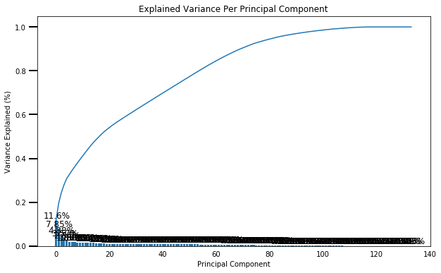

```python
pca, X_pca = do_pca(len(df_scaled.columns), df_scaled)
scree_plot(pca)
```

|  | Explained Variance | ALTERSKATEGORIE_GROB | ANREDE_KZ | CJT_GESAMTTYP | FINANZ_MINIMALIST | FINANZ_SPARER | FINANZ_VORSORGER | FINANZ_ANLEGER | FINANZ_UNAUFFAELLIGER | FINANZ_HAUSBAUER | ... | CAMEO_DEU_2015_8D | CAMEO_DEU_2015_9A | CAMEO_DEU_2015_9B | CAMEO_DEU_2015_9C | CAMEO_DEU_2015_9D | CAMEO_DEU_2015_9E | PRAEGENDE_JUGENDJAHRE_MOVEMENT | PRAEGENDE_JUGENDJAHRE_DECADES | CAMEO_INTL_2015_WEALTH | CAMEO_INTL_2015_LIFE_STAGE |
| --- | --- | --- | --- | --- | --- | --- | --- | --- | --- | --- | --- | --- | --- | --- | --- | --- | --- | --- | --- | --- | --- |
| Dimension 1 | 0.1162 | -0.0760 | 0.0073 | 0.0194 | -0.1825 | 0.0983 | -0.0772 | 0.0338 | 0.0395 | 0.1470 | ... | 0.0288 | 0.0360 | 0.0589 | 0.0584 | 0.0575 | 0.0124 | 0.1120 | 0.0664 | 0.1864 | -0.1120 |
| Dimension 2 | 0.0786 | 0.2438 | 0.0494 | -0.1214 | 0.0921 | -0.2369 | 0.2226 | -0.2010 | -0.2188 | 0.0937 | ... | 0.0373 | -0.0105 | -0.0016 | 0.0018 | 0.0062 | 0.0274 | -0.0006 | -0.2532 | 0.0421 | 0.0191 |
| Dimension 3 | 0.0488 | 0.0266 | -0.3624 | -0.0226 | 0.1472 | -0.0693 | 0.0644 | -0.1575 | -0.0679 | -0.0643 | ... | 0.0042 | -0.0046 | 0.0125 | 0.0234 | 0.0093 | 0.0020 | -0.0426 | -0.0722 | 0.0178 | -0.0117 |
| Dimension 4 | 0.0357 | 0.0125 | 0.0213 | 0.0545 | 0.0345 | -0.0172 | 0.0156 | -0.0815 | 0.0014 | -0.0343 | ... | -0.0055 | 0.0150 | 0.0098 | 0.0155 | 0.0065 | 0.0014 | -0.2109 | 0.0043 | -0.0108 | -0.0023 |
| Dimension 5 | 0.0285 | -0.0735 | 0.0273 | 0.0117 | 0.0057 | 0.0161 | -0.0387 | -0.0981 | 0.1058 | -0.0429 | ... | -0.0429 | -0.0646 | -0.0377 | -0.0132 | -0.0205 | -0.0047 | -0.2338 | 0.0350 | -0.1735 | 0.0902 |
| Dimension 6 | 0.0188 | -0.0004 | 0.0149 | 0.0072 | 0.0587 | 0.0100 | -0.0562 | 0.0458 | -0.0357 | -0.0723 | ... | -0.0498 | 0.0759 | 0.1667 | 0.1464 | 0.1098 | 0.0451 | -0.0186 | 0.0302 | -0.1039 | -0.1203 |
| Dimension 7 | 0.0184 | 0.0699 | -0.0287 | -0.0132 | -0.0262 | 0.0187 | 0.0436 | -0.0304 | 0.0597 | -0.0162 | ... | -0.1225 | 0.0538 | 0.0404 | 0.0683 | 0.0926 | 0.0100 | -0.0019 | 0.0113 | 0.0290 | -0.3439 |
| Dimension 8 | 0.0172 | 0.0095 | 0.0039 | -0.0251 | -0.0872 | 0.0075 | 0.0037 | 0.0155 | -0.0160 | 0.1165 | ... | 0.0417 | 0.0360 | 0.0248 | 0.0265 | -0.0281 | 0.0872 | 0.0634 | -0.0150 | -0.0888 | 0.1666 |
| Dimension 9 | 0.0168 | 0.0144 | -0.0067 | 0.0063 | -0.0195 | 0.0130 | -0.0222 | 0.0135 | 0.0163 | 0.0107 | ... | 0.1553 | -0.1348 | -0.1456 | -0.1469 | -0.1697 | -0.0624 | -0.0072 | 0.0189 | -0.0246 | -0.0399 |
| Dimension 10 | 0.0163 | 0.0066 | 0.0065 | 0.0060 | 0.0167 | -0.0031 | -0.0295 | 0.0059 | -0.0080 | -0.0052 | ... | -0.0508 | -0.0680 | -0.0466 | -0.0537 | -0.0675 | -0.0349 | 0.0004 | 0.0099 | 0.0550 | -0.0663 |
| Dimension 11 | 0.0162 | 0.0027 | 0.0009 | -0.0060 | -0.0085 | -0.0053 | -0.0002 | -0.0199 | -0.0030 | 0.0175 | ... | -0.0384 | -0.0133 | 0.0047 | -0.0022 | -0.0354 | 0.0195 | -0.0003 | -0.0027 | 0.0123 | 0.0211 |
| Dimension 12 | 0.0160 | -0.0139 | 0.0173 | -0.0118 | -0.0063 | -0.0108 | -0.0110 | 0.0169 | -0.0326 | 0.0307 | ... | 0.0120 | -0.0312 | -0.0093 | -0.0314 | -0.0642 | -0.0051 | 0.0007 | -0.0113 | 0.0298 | -0.0531 |
| Dimension 13 | 0.0155 | -0.1231 | 0.0723 | -0.0419 | 0.0165 | -0.1149 | 0.0960 | -0.0547 | -0.1535 | 0.1051 | ... | 0.0259 | -0.0208 | -0.0242 | -0.0473 | -0.0817 | 0.0322 | 0.0640 | -0.1278 | -0.0352 | 0.0226 |
| Dimension 14 | 0.0151 | -0.1588 | 0.0836 | -0.0309 | 0.0962 | -0.1638 | 0.1787 | -0.1341 | -0.1549 | 0.0072 | ... | -0.0103 | 0.0500 | 0.0121 | 0.0249 | 0.0922 | 0.0052 | 0.0311 | -0.1565 | 0.0280 | -0.0445 |
| Dimension 15 | 0.0143 | -0.0057 | -0.0106 | 0.0264 | -0.0173 | 0.0051 | -0.0157 | -0.0302 | 0.0160 | 0.0050 | ... | 0.0115 | -0.1148 | -0.1066 | -0.0718 | -0.1434 | 0.0311 | -0.0247 | 0.0134 | -0.0702 | 0.1939 |
| Dimension 16 | 0.0131 | 0.0075 | 0.0307 | 0.0197 | 0.1030 | -0.0089 | -0.0436 | -0.0109 | -0.0276 | -0.1331 | ... | -0.1110 | -0.0577 | 0.0686 | 0.0701 | 0.0105 | -0.0325 | -0.1117 | 0.0345 | 0.1679 | -0.3045 |
| Dimension 17 | 0.0125 | -0.0739 | -0.0028 | 0.0350 | 0.0880 | -0.0332 | 0.0525 | -0.0202 | -0.0065 | -0.1462 | ... | -0.0053 | -0.0785 | -0.1589 | -0.0499 | -0.0390 | 0.0279 | 0.0330 | -0.0030 | 0.0521 | -0.0407 |
| Dimension 18 | 0.0120 | 0.0374 | 0.0276 | -0.0844 | -0.0994 | 0.0100 | 0.0763 | -0.0747 | 0.1533 | 0.1044 | ... | -0.0712 | -0.0586 | -0.1708 | -0.0098 | 0.1265 | 0.0195 | 0.0024 | -0.0464 | -0.0773 | -0.0753 |
| Dimension 19 | 0.0112 | 0.0683 | 0.0532 | -0.0177 | 0.0028 | 0.0497 | -0.1063 | 0.1197 | 0.0690 | -0.0107 | ... | 0.1705 | -0.0302 | -0.0272 | 0.0096 | 0.1049 | 0.0648 | -0.1241 | 0.0210 | 0.1097 | 0.0894 |
| Dimension 20 | 0.0102 | -0.0096 | 0.0036 | -0.0722 | -0.0524 | 0.0137 | 0.0457 | -0.0365 | 0.0551 | 0.0582 | ... | 0.0013 | 0.2362 | 0.0590 | -0.0137 | -0.0427 | 0.1929 | -0.1804 | -0.0247 | 0.2264 | -0.0050 |
| Dimension 21 | 0.0096 | -0.0326 | -0.0059 | 0.0100 | 0.0508 | -0.0032 | -0.0183 | 0.0370 | -0.0027 | -0.0614 | ... | 0.0810 | -0.0650 | -0.0859 | -0.0055 | 0.1376 | 0.2305 | 0.0351 | 0.0146 | 0.0181 | 0.1186 |
| Dimension 22 | 0.0092 | 0.0534 | -0.0078 | 0.0260 | -0.0521 | 0.0149 | -0.0380 | 0.0318 | -0.0448 | 0.0979 | ... | -0.1725 | -0.1336 | 0.0642 | -0.0334 | -0.0815 | 0.0154 | 0.0907 | 0.0020 | -0.1483 | -0.1998 |
| Dimension 23 | 0.0086 | -0.1180 | 0.0515 | -0.1681 | -0.0703 | -0.0176 | 0.0617 | 0.0494 | 0.0185 | 0.1950 | ... | 0.0293 | -0.0115 | 0.1563 | -0.1732 | -0.0474 | -0.0872 | -0.1665 | -0.0922 | -0.0526 | -0.0937 |
| Dimension 24 | 0.0084 | 0.0662 | -0.0275 | 0.2804 | 0.0553 | -0.0207 | 0.0179 | -0.0293 | -0.0431 | -0.1802 | ... | 0.0347 | 0.1271 | -0.0637 | -0.1515 | 0.0840 | -0.0105 | -0.0410 | 0.0503 | 0.0049 | -0.0180 |
| Dimension 25 | 0.0080 | -0.0218 | 0.0116 | 0.0833 | -0.0277 | -0.0248 | 0.0279 | 0.0090 | -0.0557 | 0.1091 | ... | 0.1199 | -0.0947 | 0.0779 | -0.1993 | 0.2726 | 0.0218 | -0.0298 | -0.0414 | 0.0377 | -0.0114 |
| Dimension 26 | 0.0079 | -0.0168 | 0.0034 | -0.1950 | -0.0468 | 0.0407 | -0.0378 | 0.0221 | 0.0616 | 0.0032 | ... | 0.2651 | -0.0596 | -0.1339 | 0.1676 | 0.0253 | 0.0887 | 0.0149 | 0.0118 | 0.0140 | 0.0007 |
| Dimension 27 | 0.0079 | 0.0207 | -0.0032 | -0.0021 | 0.0120 | -0.0120 | 0.0291 | -0.0241 | 0.0132 | -0.0152 | ... | -0.2797 | 0.2148 | -0.0931 | -0.1440 | 0.0980 | -0.1139 | 0.0142 | -0.0085 | -0.0482 | 0.0094 |
| Dimension 28 | 0.0078 | 0.0056 | 0.0170 | -0.0155 | -0.0057 | -0.0017 | 0.0119 | 0.0228 | -0.0256 | 0.0319 | ... | -0.1537 | -0.1740 | 0.3493 | -0.0864 | -0.1596 | 0.0429 | -0.0320 | -0.0139 | 0.0283 | 0.0078 |
| Dimension 29 | 0.0078 | 0.0243 | 0.0078 | -0.1406 | -0.0108 | 0.0402 | -0.0460 | 0.0276 | 0.0341 | -0.0221 | ... | -0.2659 | -0.0544 | 0.1246 | 0.2555 | -0.2714 | -0.1039 | 0.0352 | 0.0195 | 0.0094 | 0.0174 |
| Dimension 30 | 0.0078 | -0.0142 | 0.0071 | 0.0682 | 0.0104 | -0.0060 | -0.0011 | -0.0026 | -0.0104 | 0.0149 | ... | 0.0915 | -0.1065 | 0.0793 | -0.2235 | 0.2227 | 0.1401 | 0.0581 | -0.0132 | 0.0195 | 0.0105 |
| ... | ... | ... | ... | ... | ... | ... | ... | ... | ... | ... | ... | ... | ... | ... | ... | ... | ... | ... | ... | ... | ... |
| Dimension 105 | 0.0011 | -0.0212 | 0.0203 | -0.0024 | -0.0082 | -0.0423 | 0.0947 | 0.0801 | 0.0795 | -0.0383 | ... | -0.0060 | -0.0146 | -0.0012 | 0.0120 | 0.0136 | 0.0039 | -0.0017 | -0.0261 | 0.0043 | -0.0079 |
| Dimension 106 | 0.0010 | 0.0351 | -0.0286 | 0.0097 | -0.1559 | 0.1418 | -0.0892 | -0.1699 | -0.1600 | 0.0512 | ... | 0.0025 | -0.0022 | 0.0099 | 0.0002 | -0.0019 | 0.0040 | -0.0032 | 0.0378 | 0.0049 | -0.0018 |
| Dimension 107 | 0.0010 | 0.1520 | -0.1402 | -0.0100 | 0.1630 | -0.1567 | 0.1615 | 0.2520 | 0.2592 | -0.0469 | ... | -0.0072 | 0.0015 | 0.0050 | 0.0033 | -0.0092 | 0.0005 | -0.0185 | -0.0951 | -0.0029 | -0.0020 |
| Dimension 108 | 0.0010 | 0.0655 | -0.0456 | 0.0070 | -0.0299 | 0.0374 | -0.0940 | -0.0663 | -0.0266 | 0.0569 | ... | -0.0033 | 0.0024 | -0.0046 | -0.0011 | 0.0026 | -0.0022 | -0.0029 | -0.0499 | -0.0049 | -0.0041 |
| Dimension 109 | 0.0009 | -0.0669 | -0.0023 | -0.0189 | 0.1555 | -0.1580 | 0.1468 | -0.1008 | -0.0320 | -0.0362 | ... | -0.0075 | -0.0009 | -0.0009 | -0.0006 | -0.0006 | 0.0039 | -0.0085 | 0.4617 | -0.0068 | -0.0040 |
| Dimension 110 | 0.0009 | -0.0020 | 0.0061 | 0.0058 | -0.0756 | 0.0460 | 0.0119 | -0.0465 | 0.0001 | -0.0068 | ... | -0.0062 | -0.0054 | 0.0048 | -0.0004 | 0.0030 | 0.0008 | 0.0027 | -0.0258 | -0.0013 | -0.0037 |
| Dimension 111 | 0.0008 | -0.1642 | 0.1421 | 0.0011 | -0.3167 | -0.0434 | 0.1331 | -0.0587 | 0.0463 | -0.1516 | ... | -0.0021 | -0.0003 | 0.0011 | -0.0052 | 0.0137 | -0.0004 | 0.0128 | -0.0060 | 0.0043 | -0.0020 |
| Dimension 112 | 0.0008 | 0.0216 | 0.0356 | -0.0086 | 0.4887 | -0.2207 | -0.4525 | 0.2616 | -0.2093 | 0.2911 | ... | 0.0028 | 0.0002 | 0.0025 | -0.0073 | -0.0016 | 0.0009 | -0.0167 | 0.0912 | -0.0022 | 0.0031 |
| Dimension 113 | 0.0006 | 0.5098 | -0.1537 | 0.0071 | 0.2718 | 0.4102 | 0.2533 | -0.1153 | 0.1344 | 0.0623 | ... | 0.0071 | -0.0053 | -0.0070 | -0.0051 | 0.0072 | 0.0061 | -0.0120 | -0.0019 | -0.0028 | 0.0057 |
| Dimension 114 | 0.0006 | 0.3541 | -0.1171 | -0.0049 | -0.2738 | -0.3913 | -0.1209 | 0.0946 | -0.0123 | -0.0646 | ... | 0.0033 | -0.0004 | 0.0014 | 0.0030 | 0.0022 | 0.0031 | 0.0061 | 0.1046 | 0.0059 | -0.0004 |
| Dimension 115 | 0.0006 | -0.3227 | 0.1084 | 0.0017 | 0.3819 | 0.3943 | 0.1128 | -0.0662 | 0.0349 | 0.1123 | ... | -0.0015 | 0.0009 | 0.0000 | -0.0036 | -0.0025 | -0.0004 | -0.0106 | -0.0846 | -0.0013 | 0.0012 |
| Dimension 116 | 0.0003 | 0.3742 | 0.8049 | -0.0001 | 0.0408 | 0.0386 | 0.0308 | -0.0288 | -0.0013 | -0.0173 | ... | 0.0010 | 0.0007 | -0.0019 | -0.0025 | 0.0013 | 0.0015 | 0.0071 | 0.0734 | -0.0007 | 0.0019 |
| Dimension 117 | 0.0002 | 0.0400 | 0.0915 | -0.0008 | 0.0239 | -0.0199 | -0.0802 | -0.0166 | -0.0063 | -0.0226 | ... | -0.0012 | -0.0043 | 0.0018 | 0.0017 | -0.0003 | 0.0027 | -0.0097 | -0.2227 | -0.0019 | -0.0007 |
| Dimension 118 | 0.0002 | 0.0491 | 0.0183 | 0.0063 | 0.0110 | -0.0975 | -0.1508 | -0.0825 | -0.0527 | -0.0571 | ... | -0.0020 | -0.0005 | -0.0007 | 0.0011 | 0.0013 | -0.0017 | -0.0013 | -0.6278 | -0.0005 | -0.0019 |
| Dimension 119 | 0.0001 | -0.0044 | 0.0026 | -0.0023 | -0.0110 | 0.0043 | -0.0075 | -0.0083 | 0.0078 | 0.0082 | ... | 0.0008 | 0.0014 | -0.0016 | -0.0013 | 0.0001 | 0.0005 | -0.0144 | -0.0003 | -0.0003 | 0.0008 |
| Dimension 120 | 0.0001 | 0.0027 | -0.0100 | -0.0027 | -0.0021 | 0.0200 | 0.0195 | 0.0373 | 0.0050 | 0.0179 | ... | -0.0003 | -0.0003 | 0.0004 | -0.0000 | -0.0002 | -0.0000 | 0.0246 | -0.0344 | -0.0000 | 0.0000 |
| Dimension 121 | 0.0000 | -0.0000 | 0.0009 | -0.0006 | -0.0078 | -0.0025 | 0.0165 | 0.0056 | -0.0008 | 0.0040 | ... | -0.0002 | 0.0011 | -0.0010 | -0.0008 | -0.0005 | 0.0000 | -0.0013 | -0.0308 | -0.0006 | 0.0004 |
| Dimension 122 | 0.0000 | -0.0000 | -0.0000 | 0.0000 | -0.0000 | 0.0000 | -0.0000 | 0.0000 | -0.0000 | 0.0000 | ... | 0.1571 | 0.0288 | -0.0109 | -0.0101 | -0.0108 | 0.0574 | 0.0559 | -0.0000 | -0.4308 | -0.3559 |
| Dimension 123 | 0.0000 | 0.0000 | -0.0000 | 0.0000 | -0.0000 | 0.0000 | 0.0000 | -0.0000 | -0.0000 | 0.0000 | ... | -0.1636 | 0.0253 | 0.0586 | 0.0546 | 0.0582 | -0.0195 | 0.4130 | 0.0000 | 0.0115 | 0.2306 |
| Dimension 124 | 0.0000 | 0.0000 | 0.0000 | 0.0000 | 0.0000 | 0.0000 | -0.0000 | -0.0000 | -0.0000 | 0.0000 | ... | 0.1896 | 0.0783 | 0.0782 | 0.0729 | 0.0777 | 0.0453 | 0.4287 | 0.0000 | 0.1697 | -0.1079 |
| Dimension 125 | 0.0000 | -0.0000 | 0.0000 | -0.0000 | -0.0000 | -0.0000 | -0.0000 | -0.0000 | -0.0000 | 0.0000 | ... | 0.0062 | 0.0511 | 0.0270 | 0.0252 | 0.0268 | 0.0543 | 0.2548 | 0.0000 | -0.2938 | -0.2622 |
| Dimension 126 | 0.0000 | 0.0000 | -0.0000 | 0.0000 | 0.0000 | 0.0000 | -0.0000 | -0.0000 | -0.0000 | 0.0000 | ... | 0.0327 | -0.1222 | -0.1267 | -0.1181 | -0.1259 | -0.0659 | 0.1245 | -0.0000 | -0.4060 | 0.1312 |
| Dimension 127 | 0.0000 | -0.0000 | 0.0000 | 0.0000 | 0.0000 | -0.0000 | 0.0000 | 0.0000 | 0.0000 | 0.0000 | ... | -0.0460 | 0.0822 | 0.1348 | 0.1257 | 0.1339 | -0.0066 | 0.0304 | 0.0000 | -0.2404 | 0.3071 |
| Dimension 128 | 0.0000 | 0.0000 | 0.0000 | 0.0000 | -0.0000 | 0.0000 | -0.0000 | -0.0000 | 0.0000 | -0.0000 | ... | -0.0275 | -0.2722 | -0.3079 | -0.2871 | -0.3059 | -0.1205 | 0.1214 | 0.0000 | 0.1970 | 0.0877 |
| Dimension 129 | 0.0000 | 0.0000 | 0.0000 | -0.0000 | 0.0000 | 0.0000 | 0.0000 | -0.0000 | 0.0000 | 0.0000 | ... | -0.0957 | 0.0743 | 0.1277 | 0.1190 | 0.1268 | -0.0119 | -0.0478 | -0.0000 | -0.0735 | 0.3240 |
| Dimension 130 | 0.0000 | -0.0000 | -0.0000 | -0.0000 | -0.0000 | -0.0000 | 0.0000 | 0.0000 | -0.0000 | -0.0000 | ... | 0.0045 | -0.0555 | -0.0862 | -0.0804 | -0.0856 | -0.0005 | -0.0785 | -0.0000 | 0.0724 | -0.1687 |
| Dimension 131 | 0.0000 | 0.0000 | 0.0000 | 0.0000 | 0.0000 | 0.0000 | 0.0000 | -0.0000 | -0.0000 | -0.0000 | ... | -0.1407 | -0.0788 | -0.1073 | -0.1000 | -0.1066 | -0.0163 | 0.1612 | -0.0000 | 0.2077 | -0.1187 |
| Dimension 132 | 0.0000 | 0.0000 | 0.0000 | 0.0000 | 0.0000 | -0.0000 | -0.0000 | 0.0000 | 0.0000 | 0.0000 | ... | 0.0832 | -0.0108 | -0.0256 | -0.0239 | -0.0254 | 0.0090 | -0.0782 | -0.0000 | -0.2491 | -0.1034 |
| Dimension 133 | 0.0000 | 0.0000 | -0.0000 | -0.0000 | -0.0000 | -0.0000 | -0.0000 | 0.0000 | 0.0000 | -0.0000 | ... | 0.0400 | 0.0031 | 0.0032 | 0.0029 | 0.0031 | 0.0017 | 0.0258 | 0.0000 | 0.0958 | -0.0036 |
| Dimension 134 | 0.0000 | -0.0000 | 0.0000 | 0.0000 | 0.0000 | 0.0000 | 0.0000 | -0.0000 | 0.0000 | 0.0000 | ... | -0.0075 | 0.0264 | 0.0055 | 0.0051 | 0.0054 | 0.0368 | -0.0728 | 0.0000 | -0.0289 | -0.2032 |

134 rows × 135 columns

[figure not shown]

```python
pca_results(df_scaled, pca)
```

```python
df_scaled.isnull().sum()
```

```
ALTERSKATEGORIE_GROB              0
ANREDE_KZ                         0
CJT_GESAMTTYP                     0
FINANZ_MINIMALIST                 0
FINANZ_SPARER                     0
FINANZ_VORSORGER                  0
FINANZ_ANLEGER                    0
FINANZ_UNAUFFAELLIGER             0
FINANZ_HAUSBAUER                  0
FINANZTYP                         0
GEBURTSJAHR                       0
GFK_URLAUBERTYP                   0
GREEN_AVANTGARDE                  0
HEALTH_TYP                        0
LP_LEBENSPHASE_FEIN               0
LP_LEBENSPHASE_GROB               0
LP_FAMILIE_FEIN                   0
LP_FAMILIE_GROB                   0
LP_STATUS_FEIN                    0
LP_STATUS_GROB                    0
NATIONALITAET_KZ                  0
RETOURTYP_BK_S                    0
SEMIO_SOZ                         0
SEMIO_FAM                         0
SEMIO_REL                         0
SEMIO_MAT                         0
SEMIO_VERT                        0
SEMIO_LUST                        0
SEMIO_ERL                         0
SEMIO_KULT                        0
                                 ..
CAMEO_DEU_2015_5A                 0
CAMEO_DEU_2015_5B                 0
CAMEO_DEU_2015_5C                 0
CAMEO_DEU_2015_5D                 0
CAMEO_DEU_2015_5E                 0
CAMEO_DEU_2015_5F                 0
CAMEO_DEU_2015_6A                 0
CAMEO_DEU_2015_6B                 0
CAMEO_DEU_2015_6C                 0
CAMEO_DEU_2015_6D                 0
CAMEO_DEU_2015_6E                 0
CAMEO_DEU_2015_6F                 0
CAMEO_DEU_2015_7A                 0
CAMEO_DEU_2015_7B                 0
CAMEO_DEU_2015_7C                 0
CAMEO_DEU_2015_7D                 0
CAMEO_DEU_2015_7E                 0
CAMEO_DEU_2015_8A                 0
CAMEO_DEU_2015_8B                 0
CAMEO_DEU_2015_8C                 0
CAMEO_DEU_2015_8D                 0
CAMEO_DEU_2015_9A                 0
CAMEO_DEU_2015_9B                 0
CAMEO_DEU_2015_9C                 0
CAMEO_DEU_2015_9D                 0
CAMEO_DEU_2015_9E                 0
PRAEGENDE_JUGENDJAHRE_MOVEMENT    0
PRAEGENDE_JUGENDJAHRE_DECADES     0
CAMEO_INTL_2015_WEALTH            0
CAMEO_INTL_2015_LIFE_STAGE        0
Length: 134, dtype: int64
```

```
Using 60 components, we can explain 0.8367000000000001% of the variability in the original data.
```

[figure not shown]

```python
# Re-apply PCA to the data while selecting for number of components to retain.
for comp in range(60, df_clean.shape[1],5):
    pca, X_pca = do_pca(comp, df_scaled)
    comp_check = pca_results(df_scaled, pca)
    if comp_check['Explained Variance'].sum() > 0.8:
        break


num_comps = comp_check.shape[0]
print("Using {} components, we can explain {}% of the variability in the original data.".format(comp_check.shape[0],comp_check['Explained Variance'].sum()))
```

|  | Explained Variance | ALTERSKATEGORIE_GROB | ANREDE_KZ | CJT_GESAMTTYP | FINANZ_MINIMALIST | FINANZ_SPARER | FINANZ_VORSORGER | FINANZ_ANLEGER | FINANZ_UNAUFFAELLIGER | FINANZ_HAUSBAUER | ... | CAMEO_DEU_2015_8D | CAMEO_DEU_2015_9A | CAMEO_DEU_2015_9B | CAMEO_DEU_2015_9C | CAMEO_DEU_2015_9D | CAMEO_DEU_2015_9E | PRAEGENDE_JUGENDJAHRE_MOVEMENT | PRAEGENDE_JUGENDJAHRE_DECADES | CAMEO_INTL_2015_WEALTH | CAMEO_INTL_2015_LIFE_STAGE |
| --- | --- | --- | --- | --- | --- | --- | --- | --- | --- | --- | --- | --- | --- | --- | --- | --- | --- | --- | --- | --- | --- |
| Dimension 1 | 0.1162 | -0.0760 | 0.0073 | 0.0194 | -0.1825 | 0.0983 | -0.0772 | 0.0338 | 0.0395 | 0.1470 | ... | 0.0288 | 0.0360 | 0.0589 | 0.0584 | 0.0575 | 0.0124 | 0.1120 | 0.0664 | 0.1864 | -0.1120 |
| Dimension 2 | 0.0786 | 0.2438 | 0.0494 | -0.1214 | 0.0921 | -0.2369 | 0.2226 | -0.2010 | -0.2188 | 0.0937 | ... | 0.0373 | -0.0105 | -0.0016 | 0.0018 | 0.0062 | 0.0274 | -0.0006 | -0.2532 | 0.0421 | 0.0191 |
| Dimension 3 | 0.0488 | 0.0266 | -0.3624 | -0.0226 | 0.1472 | -0.0693 | 0.0644 | -0.1575 | -0.0679 | -0.0643 | ... | 0.0042 | -0.0046 | 0.0125 | 0.0234 | 0.0093 | 0.0020 | -0.0426 | -0.0722 | 0.0178 | -0.0117 |
| Dimension 4 | 0.0357 | 0.0125 | 0.0213 | 0.0545 | 0.0345 | -0.0172 | 0.0156 | -0.0815 | 0.0014 | -0.0343 | ... | -0.0055 | 0.0150 | 0.0098 | 0.0155 | 0.0065 | 0.0014 | -0.2109 | 0.0043 | -0.0108 | -0.0023 |
| Dimension 5 | 0.0285 | -0.0735 | 0.0273 | 0.0117 | 0.0058 | 0.0161 | -0.0387 | -0.0981 | 0.1058 | -0.0429 | ... | -0.0429 | -0.0646 | -0.0377 | -0.0132 | -0.0205 | -0.0047 | -0.2338 | 0.0350 | -0.1735 | 0.0902 |
| Dimension 6 | 0.0188 | -0.0003 | 0.0148 | 0.0075 | 0.0588 | 0.0100 | -0.0562 | 0.0459 | -0.0357 | -0.0723 | ... | -0.0500 | 0.0763 | 0.1669 | 0.1463 | 0.1092 | 0.0450 | -0.0184 | 0.0302 | -0.1041 | -0.1202 |
| Dimension 7 | 0.0184 | 0.0700 | -0.0288 | -0.0130 | -0.0262 | 0.0188 | 0.0435 | -0.0303 | 0.0597 | -0.0163 | ... | -0.1228 | 0.0543 | 0.0406 | 0.0682 | 0.0921 | 0.0098 | -0.0017 | 0.0113 | 0.0288 | -0.3439 |
| Dimension 8 | 0.0172 | 0.0092 | 0.0040 | -0.0249 | -0.0875 | 0.0074 | 0.0039 | 0.0155 | -0.0160 | 0.1170 | ... | 0.0419 | 0.0355 | 0.0241 | 0.0262 | -0.0270 | 0.0873 | 0.0625 | -0.0151 | -0.0887 | 0.1665 |
| Dimension 9 | 0.0168 | 0.0146 | -0.0067 | 0.0066 | -0.0195 | 0.0131 | -0.0224 | 0.0136 | 0.0164 | 0.0105 | ... | 0.1550 | -0.1341 | -0.1457 | -0.1473 | -0.1705 | -0.0623 | -0.0069 | 0.0190 | -0.0249 | -0.0400 |
| Dimension 10 | 0.0163 | 0.0066 | 0.0065 | 0.0060 | 0.0168 | -0.0031 | -0.0294 | 0.0057 | -0.0081 | -0.0051 | ... | -0.0512 | -0.0683 | -0.0462 | -0.0537 | -0.0670 | -0.0352 | 0.0003 | 0.0098 | 0.0552 | -0.0662 |
| Dimension 11 | 0.0162 | 0.0025 | 0.0010 | -0.0067 | -0.0084 | -0.0054 | -0.0002 | -0.0198 | -0.0033 | 0.0173 | ... | -0.0383 | -0.0137 | 0.0048 | -0.0019 | -0.0354 | 0.0195 | -0.0002 | -0.0028 | 0.0126 | 0.0210 |
| Dimension 12 | 0.0160 | -0.0138 | 0.0174 | -0.0114 | -0.0064 | -0.0108 | -0.0110 | 0.0169 | -0.0326 | 0.0307 | ... | 0.0123 | -0.0307 | -0.0092 | -0.0315 | -0.0649 | -0.0051 | 0.0009 | -0.0113 | 0.0296 | -0.0531 |
| Dimension 13 | 0.0155 | -0.1238 | 0.0725 | -0.0418 | 0.0161 | -0.1154 | 0.0966 | -0.0553 | -0.1537 | 0.1064 | ... | 0.0259 | -0.0225 | -0.0253 | -0.0474 | -0.0786 | 0.0321 | 0.0623 | -0.1285 | -0.0348 | 0.0227 |
| Dimension 14 | 0.0151 | -0.1585 | 0.0836 | -0.0290 | 0.0965 | -0.1640 | 0.1787 | -0.1346 | -0.1548 | 0.0073 | ... | -0.0121 | 0.0514 | 0.0130 | 0.0236 | 0.0900 | 0.0043 | 0.0315 | -0.1565 | 0.0272 | -0.0441 |
| Dimension 15 | 0.0143 | -0.0054 | -0.0108 | 0.0247 | -0.0180 | 0.0060 | -0.0165 | -0.0291 | 0.0165 | 0.0044 | ... | 0.0137 | -0.1158 | -0.1080 | -0.0709 | -0.1425 | 0.0325 | -0.0253 | 0.0142 | -0.0699 | 0.1942 |
| Dimension 16 | 0.0131 | 0.0069 | 0.0310 | 0.0198 | 0.1027 | -0.0092 | -0.0430 | -0.0113 | -0.0279 | -0.1323 | ... | -0.1107 | -0.0590 | 0.0681 | 0.0702 | 0.0125 | -0.0325 | -0.1129 | 0.0341 | 0.1686 | -0.3045 |
| Dimension 17 | 0.0125 | -0.0738 | -0.0027 | 0.0345 | 0.0878 | -0.0332 | 0.0531 | -0.0200 | -0.0070 | -0.1462 | ... | -0.0040 | -0.0791 | -0.1587 | -0.0492 | -0.0392 | 0.0280 | 0.0326 | -0.0027 | 0.0524 | -0.0405 |
| Dimension 18 | 0.0120 | 0.0374 | 0.0276 | -0.0863 | -0.0993 | 0.0106 | 0.0755 | -0.0740 | 0.1537 | 0.1032 | ... | -0.0700 | -0.0601 | -0.1717 | -0.0082 | 0.1269 | 0.0206 | 0.0032 | -0.0458 | -0.0769 | -0.0749 |
| Dimension 19 | 0.0112 | 0.0677 | 0.0532 | -0.0156 | 0.0046 | 0.0481 | -0.1058 | 0.1180 | 0.0681 | -0.0098 | ... | 0.1666 | -0.0331 | -0.0225 | 0.0101 | 0.1066 | 0.0612 | -0.1238 | 0.0198 | 0.1118 | 0.0892 |
| Dimension 20 | 0.0102 | -0.0076 | 0.0024 | -0.0739 | -0.0520 | 0.0151 | 0.0448 | -0.0361 | 0.0557 | 0.0548 | ... | 0.0013 | 0.2377 | 0.0622 | -0.0096 | -0.0514 | 0.1920 | -0.1774 | -0.0226 | 0.2258 | -0.0053 |
| Dimension 21 | 0.0096 | -0.0331 | -0.0076 | 0.0069 | 0.0487 | -0.0012 | -0.0208 | 0.0388 | 0.0022 | -0.0625 | ... | 0.0929 | -0.0633 | -0.1004 | -0.0030 | 0.1415 | 0.2451 | 0.0355 | 0.0156 | 0.0163 | 0.1182 |
| Dimension 22 | 0.0092 | 0.0488 | -0.0063 | 0.0231 | -0.0561 | 0.0141 | -0.0376 | 0.0328 | -0.0447 | 0.1056 | ... | -0.1695 | -0.1473 | 0.0533 | -0.0378 | -0.0568 | 0.0158 | 0.0818 | -0.0014 | -0.1493 | -0.2022 |
| Dimension 23 | 0.0086 | -0.1122 | 0.0480 | -0.1681 | -0.0652 | -0.0151 | 0.0581 | 0.0499 | 0.0194 | 0.1807 | ... | 0.0175 | 0.0092 | 0.1678 | -0.1803 | -0.0717 | -0.0895 | -0.1584 | -0.0874 | -0.0559 | -0.0916 |
| Dimension 24 | 0.0084 | 0.0693 | -0.0287 | 0.2998 | 0.0583 | -0.0246 | 0.0201 | -0.0340 | -0.0483 | -0.1814 | ... | 0.0404 | 0.1250 | -0.0788 | -0.1605 | 0.1093 | -0.0032 | -0.0381 | 0.0500 | 0.0061 | -0.0169 |
| Dimension 25 | 0.0080 | -0.0196 | 0.0104 | 0.0693 | -0.0259 | -0.0203 | 0.0238 | 0.0131 | -0.0517 | 0.1047 | ... | 0.1164 | -0.0699 | 0.1164 | -0.1806 | 0.1972 | 0.0239 | -0.0225 | -0.0379 | 0.0405 | -0.0071 |
| Dimension 26 | 0.0079 | -0.0041 | 0.0028 | -0.1825 | -0.0408 | 0.0366 | -0.0298 | 0.0226 | 0.0503 | 0.0023 | ... | 0.1786 | -0.0017 | -0.0120 | 0.0930 | -0.0704 | 0.0400 | 0.0060 | 0.0103 | 0.0153 | 0.0026 |
| Dimension 27 | 0.0078 | 0.0234 | -0.0060 | 0.0300 | 0.0211 | -0.0198 | 0.0371 | -0.0242 | -0.0020 | -0.0092 | ... | -0.2807 | 0.2134 | -0.0372 | -0.1964 | 0.0972 | -0.1084 | 0.0108 | -0.0146 | -0.0394 | 0.0124 |
| Dimension 28 | 0.0078 | 0.0018 | -0.0146 | -0.0584 | -0.0007 | 0.0143 | -0.0207 | -0.0161 | 0.0372 | -0.0317 | ... | 0.0715 | 0.1482 | -0.3262 | 0.2011 | 0.1033 | -0.1443 | 0.0430 | 0.0199 | -0.0178 | -0.0025 |
| Dimension 29 | 0.0077 | -0.0004 | 0.0195 | -0.0256 | -0.0033 | 0.0201 | -0.0270 | 0.0219 | 0.0106 | 0.0041 | ... | -0.0758 | -0.1543 | 0.1562 | 0.0113 | -0.0262 | 0.0756 | 0.0533 | -0.0012 | 0.0267 | 0.0175 |
| Dimension 30 | 0.0077 | 0.0177 | 0.0063 | -0.1442 | -0.0177 | 0.0228 | -0.0163 | 0.0171 | 0.0268 | -0.0070 | ... | -0.2665 | -0.0980 | -0.0971 | 0.4156 | -0.2101 | -0.1326 | -0.0240 | 0.0118 | -0.0182 | -0.0042 |
| Dimension 31 | 0.0077 | -0.0097 | 0.0034 | 0.0673 | 0.0085 | -0.0070 | 0.0038 | -0.0005 | -0.0126 | 0.0014 | ... | 0.3547 | 0.3805 | -0.2049 | 0.1184 | -0.1798 | -0.1040 | 0.0046 | -0.0029 | -0.0192 | -0.0204 |
| Dimension 32 | 0.0077 | 0.0251 | -0.0005 | 0.0111 | 0.0122 | 0.0061 | -0.0127 | -0.0015 | -0.0032 | -0.0380 | ... | -0.0345 | 0.1783 | 0.2014 | -0.1256 | -0.1858 | -0.1616 | 0.0117 | 0.0096 | 0.0058 | 0.0217 |
| Dimension 33 | 0.0077 | 0.0032 | 0.0000 | -0.0010 | -0.0056 | -0.0072 | 0.0076 | -0.0078 | 0.0085 | -0.0004 | ... | 0.2173 | 0.0697 | 0.2327 | -0.0509 | -0.2728 | 0.0876 | -0.0016 | -0.0090 | -0.0025 | -0.0032 |
| Dimension 34 | 0.0076 | 0.0028 | -0.0005 | -0.0060 | 0.0015 | -0.0024 | 0.0039 | -0.0184 | 0.0222 | -0.0244 | ... | -0.1698 | 0.0150 | 0.0914 | -0.2508 | 0.0834 | 0.1270 | 0.0673 | -0.0032 | 0.0003 | 0.0050 |
| Dimension 35 | 0.0076 | 0.0046 | -0.0050 | 0.0082 | -0.0083 | -0.0018 | -0.0000 | -0.0019 | -0.0050 | 0.0106 | ... | 0.0963 | -0.0629 | -0.0229 | 0.0616 | 0.0161 | -0.0155 | -0.0206 | 0.0014 | -0.0056 | 0.0000 |
| Dimension 36 | 0.0076 | -0.0007 | 0.0023 | -0.0403 | -0.0102 | 0.0118 | -0.0118 | 0.0239 | -0.0014 | -0.0048 | ... | -0.1001 | -0.0190 | 0.0356 | -0.0609 | 0.0717 | -0.1495 | -0.0474 | 0.0184 | 0.0069 | -0.0030 |
| Dimension 37 | 0.0076 | 0.0034 | -0.0048 | -0.0560 | -0.0032 | 0.0008 | -0.0002 | -0.0035 | 0.0081 | 0.0077 | ... | 0.0542 | -0.0519 | 0.0244 | 0.0295 | 0.0262 | -0.1010 | -0.0162 | -0.0010 | -0.0005 | 0.0061 |
| Dimension 38 | 0.0076 | 0.0223 | -0.0141 | -0.0673 | 0.0153 | 0.0113 | -0.0188 | -0.0076 | 0.0275 | -0.0616 | ... | 0.2748 | -0.1466 | 0.2121 | -0.2113 | 0.1365 | -0.2009 | -0.0034 | 0.0359 | -0.0270 | 0.0006 |
| Dimension 39 | 0.0076 | 0.0029 | 0.0008 | 0.0307 | 0.0079 | -0.0007 | 0.0038 | -0.0035 | -0.0043 | -0.0205 | ... | -0.0691 | 0.0667 | -0.0719 | -0.0531 | -0.0357 | 0.3673 | -0.0054 | -0.0067 | -0.0279 | -0.0006 |
| Dimension 40 | 0.0076 | -0.0023 | 0.0116 | 0.0397 | -0.0032 | -0.0136 | 0.0286 | 0.0013 | -0.0212 | 0.0197 | ... | 0.0657 | -0.0363 | -0.0109 | 0.1029 | -0.0246 | -0.0846 | -0.0108 | -0.0171 | -0.0076 | 0.0141 |
| Dimension 41 | 0.0075 | -0.0005 | -0.0015 | 0.0706 | -0.0094 | -0.0109 | 0.0124 | -0.0138 | -0.0071 | 0.0201 | ... | 0.0136 | -0.1099 | 0.0118 | 0.0906 | -0.0109 | 0.0376 | 0.0205 | -0.0084 | -0.0029 | 0.0031 |
| Dimension 42 | 0.0075 | -0.0071 | 0.0010 | 0.0556 | 0.0075 | -0.0111 | 0.0107 | -0.0171 | -0.0034 | 0.0017 | ... | -0.0167 | -0.1238 | 0.0342 | 0.0791 | -0.0021 | 0.0628 | 0.0231 | -0.0053 | -0.0028 | 0.0012 |
| Dimension 43 | 0.0075 | -0.0057 | 0.0031 | -0.0122 | 0.0026 | -0.0024 | 0.0021 | 0.0096 | -0.0085 | 0.0008 | ... | -0.0768 | 0.1122 | -0.0487 | -0.0362 | -0.0190 | 0.0055 | -0.0120 | -0.0084 | -0.0038 | 0.0002 |
| Dimension 44 | 0.0075 | 0.0014 | -0.0016 | 0.0595 | 0.0140 | -0.0133 | 0.0185 | -0.0129 | -0.0157 | -0.0066 | ... | 0.0521 | 0.0401 | -0.0294 | 0.0127 | -0.0312 | 0.0645 | 0.0115 | -0.0105 | 0.0050 | 0.0018 |
| Dimension 45 | 0.0075 | -0.0108 | 0.0062 | 0.0070 | -0.0075 | -0.0044 | 0.0124 | 0.0074 | -0.0128 | 0.0291 | ... | -0.0823 | 0.0493 | -0.0948 | 0.0476 | 0.0002 | 0.0442 | -0.0120 | -0.0179 | -0.0025 | -0.0006 |
| Dimension 46 | 0.0075 | 0.0071 | -0.0044 | -0.0127 | -0.0109 | 0.0041 | -0.0027 | -0.0000 | -0.0003 | 0.0100 | ... | 0.0493 | -0.0765 | 0.0303 | -0.0039 | 0.0851 | -0.1488 | -0.0061 | 0.0074 | -0.0038 | 0.0039 |
| Dimension 47 | 0.0075 | 0.0096 | -0.0114 | -0.0802 | 0.0046 | 0.0114 | -0.0123 | 0.0052 | 0.0171 | -0.0263 | ... | -0.0195 | 0.0199 | 0.0469 | -0.0976 | 0.0358 | -0.0408 | -0.0040 | 0.0164 | -0.0243 | -0.0011 |
| Dimension 48 | 0.0075 | 0.0096 | -0.0092 | 0.1144 | 0.0044 | -0.0176 | 0.0255 | -0.0175 | -0.0403 | 0.0095 | ... | -0.0131 | 0.0005 | -0.0471 | 0.1293 | -0.1028 | 0.1560 | 0.0366 | -0.0161 | 0.0130 | 0.0133 |
| Dimension 49 | 0.0075 | -0.0127 | 0.0017 | 0.0223 | 0.0065 | -0.0149 | 0.0284 | -0.0184 | 0.0051 | 0.0045 | ... | 0.0263 | -0.1383 | 0.0323 | -0.0353 | 0.0944 | 0.1113 | -0.0107 | -0.0170 | -0.0042 | 0.0043 |
| Dimension 50 | 0.0074 | 0.0001 | 0.0118 | 0.1064 | 0.0048 | -0.0136 | 0.0161 | 0.0183 | -0.0527 | 0.0177 | ... | -0.0639 | 0.0750 | -0.0431 | 0.0465 | -0.0398 | -0.1637 | -0.0735 | -0.0173 | 0.0028 | 0.0006 |
| Dimension 51 | 0.0074 | -0.0169 | 0.0277 | 0.0889 | 0.0101 | -0.0428 | 0.0640 | -0.0143 | -0.0472 | 0.0565 | ... | 0.0553 | 0.1270 | -0.0929 | 0.1576 | -0.1259 | -0.0980 | 0.0190 | -0.0627 | 0.0179 | -0.0147 |
| Dimension 52 | 0.0074 | -0.0034 | 0.0087 | -0.0437 | -0.0082 | 0.0077 | -0.0047 | 0.0479 | -0.0278 | 0.0408 | ... | -0.0620 | 0.1913 | -0.1944 | 0.0122 | 0.1010 | -0.1711 | -0.0613 | -0.0135 | 0.0291 | 0.0116 |
| Dimension 53 | 0.0073 | 0.0359 | -0.0194 | -0.1671 | -0.0080 | 0.0501 | -0.0892 | 0.0344 | 0.0330 | -0.0603 | ... | -0.1027 | 0.2077 | -0.0645 | -0.2709 | 0.1515 | -0.0743 | 0.0485 | 0.0496 | 0.0021 | 0.0093 |
| Dimension 54 | 0.0073 | 0.0285 | -0.0205 | 0.0190 | 0.0091 | 0.0170 | -0.0343 | -0.0050 | 0.0228 | -0.0559 | ... | 0.0270 | -0.2313 | 0.1374 | 0.1918 | -0.1039 | -0.1033 | -0.0556 | 0.0423 | -0.0148 | -0.0013 |
| Dimension 55 | 0.0072 | -0.0256 | 0.0038 | -0.0350 | 0.0209 | 0.0008 | -0.0022 | -0.0025 | -0.0086 | -0.0078 | ... | 0.0967 | -0.0173 | 0.0028 | -0.0101 | 0.1036 | -0.2001 | -0.0663 | 0.0004 | 0.0261 | -0.0170 |
| Dimension 56 | 0.0072 | -0.0054 | 0.0091 | 0.1019 | 0.0141 | -0.0181 | 0.0334 | 0.0032 | -0.0206 | 0.0342 | ... | 0.0549 | -0.0948 | -0.0819 | -0.0042 | 0.2176 | -0.2877 | 0.1054 | -0.0116 | -0.0116 | 0.0083 |
| Dimension 57 | 0.0071 | 0.0138 | -0.0161 | -0.1587 | -0.0019 | 0.0300 | -0.0362 | 0.0369 | -0.0001 | -0.0594 | ... | -0.0593 | 0.0448 | 0.0157 | -0.0390 | -0.0269 | -0.0088 | -0.0572 | 0.0335 | 0.0119 | 0.0186 |
| Dimension 58 | 0.0070 | 0.0031 | -0.0116 | 0.1466 | -0.0284 | -0.0208 | 0.0320 | -0.0230 | -0.0592 | 0.0891 | ... | 0.0359 | -0.1855 | -0.0635 | 0.1269 | 0.1884 | -0.1133 | -0.0173 | -0.0163 | -0.0136 | -0.0454 |
| Dimension 59 | 0.0068 | -0.0090 | 0.0081 | -0.1410 | 0.0143 | 0.0194 | -0.0890 | 0.0706 | 0.0067 | -0.0019 | ... | 0.1154 | 0.0580 | 0.0609 | 0.0041 | -0.1136 | 0.0988 | -0.0737 | 0.0206 | 0.0183 | 0.0289 |
| Dimension 60 | 0.0067 | 0.0307 | -0.0244 | 0.0263 | 0.0085 | -0.0153 | 0.0170 | -0.0423 | 0.0286 | 0.0213 | ... | 0.1430 | -0.0757 | 0.1170 | -0.0705 | 0.0400 | -0.0671 | 0.0128 | -0.0208 | 0.0216 | 0.0174 |

60 rows × 135 columns

[figure not shown]

```python
# To keep 80% of variance, we will use 60 components
num_comps = 60
pca, X_pca = do_pca(num_comps, df_scaled)
comp_check = pca_results(df_scaled, pca)
comp_check
```

### Discussion 2.2: Perform Dimensionality Reduction

According to the scree plot, we see that the explained variance grows linearly from 20 to 80 components. To keep at least 80% of the variance, we choose the first 60 components. It still looks a great number, but I hope to get some usefull insights before any further exploration.

### Step 2.3: Interpret Principal Components

Now that we have our transformed principal components, it's a nice idea to check out the weight of each variable on the first few components to see if they can be interpreted in some fashion.

As a reminder, each principal component is a unit vector that points in the direction of highest variance (after accounting for the variance captured by earlier principal components). The further a weight is from zero, the more the principal component is in the direction of the corresponding feature. If two features have large weights of the same sign (both positive or both negative), then increases in one tend expect to be associated with increases in the other. To contrast, features with different signs can be expected to show a negative correlation: increases in one variable should result in a decrease in the other.

- To investigate the features, you should map each weight to their corresponding feature name, then sort the features according to weight. The most interesting features for each principal component, then, will be those at the beginning and end of the sorted list. Use the data dictionary document to help you understand these most prominent features, their relationships, and what a positive or negative value on the principal component might indicate.
- You should investigate and interpret feature associations from the first three principal components in this substep. To help facilitate this, you should write a function that you can call at any time to print the sorted list of feature weights, for the *i*-th principal component. This might come in handy in the next step of the project, when you interpret the tendencies of the discovered clusters.

```python
# Map weights for the first principal component to corresponding feature names
# and then print the linked values, sorted by weight.
# HINT: Try defining a function here or in a new cell that you can reuse in the
# other cells.
```

```python
pca.components_
```

```
array([[-0.07598669,  0.00727356,  0.01941605, ...,  0.06642203,
         0.18641978, -0.11200498],
       [ 0.24379477,  0.04940223, -0.12142832, ..., -0.25324598,
         0.04210132,  0.01913238],
       [ 0.02662027, -0.36238918, -0.02260386, ..., -0.07218892,
         0.01779002, -0.01174779],
       ...,
       [ 0.00311982, -0.01157114,  0.14660418, ..., -0.01629635,
        -0.01363718, -0.04544174],
       [-0.00900772,  0.00813561, -0.14104147, ...,  0.02059385,
         0.01828837,  0.0289393 ],
       [ 0.03074575, -0.02444823,  0.02629355, ..., -0.02080394,
         0.02162763,  0.0173534 ]])
```

```python
pd.DataFrame(pca.components_).head()
```

|  | 0 | 1 | 2 | 3 | 4 | 5 | 6 | 7 | 8 | 9 | ... | 124 | 125 | 126 | 127 | 128 | 129 | 130 | 131 | 132 | 133 |
| --- | --- | --- | --- | --- | --- | --- | --- | --- | --- | --- | --- | --- | --- | --- | --- | --- | --- | --- | --- | --- | --- |
| 0 | -0.075987 | 0.007274 | 0.019416 | -0.182467 | 0.098337 | -0.077244 | 0.033818 | 0.039477 | 0.146968 | -0.041007 | ... | 0.028760 | 0.035966 | 0.058927 | 0.058449 | 0.057518 | 0.012414 | 0.112021 | 0.066422 | 0.186420 | -0.112005 |
| 1 | 0.243795 | 0.049402 | -0.121428 | 0.092141 | -0.236882 | 0.222607 | -0.200984 | -0.218823 | 0.093665 | 0.106093 | ... | 0.037341 | -0.010539 | -0.001618 | 0.001831 | 0.006165 | 0.027366 | -0.000611 | -0.253246 | 0.042101 | 0.019132 |
| 2 | 0.026620 | -0.362389 | -0.022604 | 0.147213 | -0.069304 | 0.064398 | -0.157526 | -0.067942 | -0.064284 | 0.103131 | ... | 0.004164 | -0.004561 | 0.012466 | 0.023419 | 0.009261 | 0.001988 | -0.042649 | -0.072189 | 0.017790 | -0.011748 |
| 3 | 0.012522 | 0.021336 | 0.054512 | 0.034523 | -0.017205 | 0.015629 | -0.081500 | 0.001403 | -0.034264 | 0.021251 | ... | -0.005481 | 0.015033 | 0.009797 | 0.015491 | 0.006493 | 0.001379 | -0.210906 | 0.004349 | -0.010796 | -0.002322 |
| 4 | -0.073527 | 0.027297 | 0.011718 | 0.005757 | 0.016099 | -0.038706 | -0.098077 | 0.105756 | -0.042929 | -0.070072 | ... | -0.042877 | -0.064610 | -0.037684 | -0.013209 | -0.020513 | -0.004654 | -0.233800 | 0.034988 | -0.173487 | 0.090219 |

5 rows × 134 columns

```python
pca_df = pd.DataFrame(pca.components_, columns=list(df_scaled.columns.values))
pca_component = pd.DataFrame(pca_df.iloc[0])
pca_component.sort_values(0, ascending=False)
```

|  | 0 |
| --- | --- |
| PLZ8_ANTG3 | 0.187816 |
| CAMEO_INTL_2015_WEALTH | 0.186420 |
| HH_EINKOMMEN_SCORE | 0.182454 |
| PLZ8_ANTG4 | 0.181944 |
| PLZ8_BAUMAX | 0.179318 |
| ORTSGR_KLS9 | 0.158718 |
| EWDICHTE | 0.156130 |
| FINANZ_HAUSBAUER | 0.146968 |
| ZABEOTYP | 0.137930 |
| KBA05_ANTG4 | 0.128284 |
| PLZ8_ANTG2 | 0.125744 |
| KBA05_ANTG3 | 0.122117 |
| ANZ_HAUSHALTE_AKTIV | 0.121398 |
| ARBEIT | 0.120460 |
| CAMEO_DEUG_2015_9 | 0.112868 |
| PRAEGENDE_JUGENDJAHRE_MOVEMENT | 0.112021 |
| RELAT_AB | 0.108163 |
| FINANZ_SPARER | 0.098337 |
| CAMEO_DEUG_2015_8 | 0.096029 |
| SEMIO_PFLICHT | 0.069820 |
| PRAEGENDE_JUGENDJAHRE_DECADES | 0.066422 |
| GEBURTSJAHR | 0.065706 |
| SEMIO_REL | 0.065259 |
| REGIOTYP | 0.064127 |
| CAMEO_DEU_2015_8A | 0.064077 |
| GEBAEUDETYP | 0.061862 |
| W_KEIT_KIND_HH | 0.060765 |
| SEMIO_TRADV | 0.060018 |
| GFK_URLAUBERTYP | 0.059317 |
| CAMEO_DEU_2015_9B | 0.058927 |
| ... | ... |
| ONLINE_AFFINITAET | -0.054847 |
| OST_WEST_KZ | -0.056397 |
| SEMIO_LUST | -0.057712 |
| WOHNLAGE | -0.062941 |
| CAMEO_DEUG_2015_3 | -0.065201 |
| KBA13_ANZAHL_PKW | -0.067171 |
| WOHNDAUER_2008 | -0.070336 |
| ALTERSKATEGORIE_GROB | -0.075987 |
| CAMEO_DEUG_2015_4 | -0.076515 |
| FINANZ_VORSORGER | -0.077244 |
| CAMEO_DEUG_2015_2 | -0.086810 |
| GEBAEUDETYP_RASTER | -0.095193 |
| BALLRAUM | -0.099378 |
| LP_FAMILIE_FEIN | -0.105267 |
| ANZ_PERSONEN | -0.105805 |
| LP_FAMILIE_GROB | -0.107231 |
| CAMEO_INTL_2015_LIFE_STAGE | -0.112005 |
| GREEN_AVANTGARDE | -0.112021 |
| INNENSTADT | -0.131858 |
| KONSUMNAEHE | -0.136593 |
| LP_LEBENSPHASE_GROB | -0.139147 |
| PLZ8_GBZ | -0.141784 |
| LP_LEBENSPHASE_FEIN | -0.151684 |
| FINANZ_MINIMALIST | -0.182467 |
| KBA05_GBZ | -0.185385 |
| PLZ8_ANTG1 | -0.189546 |
| KBA05_ANTG1 | -0.195911 |
| LP_STATUS_GROB | -0.203351 |
| LP_STATUS_FEIN | -0.205869 |
| MOBI_REGIO | -0.208667 |

134 rows × 1 columns

```python
def get_component_weights(df, pca,  component):
    pca_df = pd.DataFrame(pca.components_, columns=list(df.columns.values))
    pca_component = pd.DataFrame(pca_df.iloc[component])
    print("Top 5: ",pca_component.nlargest(5, columns=[component]))
    print("Top -5:", pca_component.nsmallest(5,columns=[component]))
```

```python
get_component_weights(df_scaled, pca, 0)
```

```
Top 5:                                 0
PLZ8_ANTG3              0.187816
CAMEO_INTL_2015_WEALTH  0.186420
HH_EINKOMMEN_SCORE      0.182454
PLZ8_ANTG4              0.181944
PLZ8_BAUMAX             0.179318
Top -5:                        0
MOBI_REGIO     -0.208667
LP_STATUS_FEIN -0.205869
LP_STATUS_GROB -0.203351
KBA05_ANTG1    -0.195911
PLZ8_ANTG1     -0.189546
```

```python
# Map weights for the second principal component to corresponding feature names
# and then print the linked values, sorted by weight.

get_component_weights(df_scaled, pca, 1)
```

```
Top 5:                               1
ALTERSKATEGORIE_GROB  0.243795
FINANZ_VORSORGER      0.222607
SEMIO_ERL             0.198055
SEMIO_LUST            0.170112
RETOURTYP_BK_S        0.162352
Top -5:                                       1
GEBURTSJAHR                   -0.259207
PRAEGENDE_JUGENDJAHRE_DECADES -0.253246
ALTER_HH                      -0.239925
FINANZ_SPARER                 -0.236882
SEMIO_REL                     -0.231605
```

```python
# Map weights for the third principal component to corresponding feature names
# and then print the linked values, sorted by weight.

get_component_weights(df_scaled, pca, 2)
```

```
Top 5:                            2
SEMIO_VERT         0.336331
SEMIO_FAM          0.272940
SEMIO_SOZ          0.269171
SEMIO_KULT         0.259842
FINANZ_MINIMALIST  0.147213
Top -5:                    2
ANREDE_KZ  -0.362389
SEMIO_KAEM -0.337087
SEMIO_DOM  -0.306795
SEMIO_KRIT -0.269177
SEMIO_ERL  -0.206727
```

## Component 0

- Top 5:
  - PLZ8_ANTG3 0.187816 - 6-10 family houses
  - CAMEO_INTL_2015_WEALTH 0.186420 - High: Poor - Low: Wealth
  - HH_EINKOMMEN_SCORE 0.182454 - Net income: Low: high income, High: low income
  - PLZ8_ANTG4 0.181944 - +10 family houses
  - PLZ8_BAUMAX 0.179318 - Most common building type - Low: small family houses, High: 10+ family homes
- Top -5:
  - MOBI_REGIO -0.208667 - Movement patterns: Low: High movement, High, Low Movement
  - LP_STATUS_FEIN -0.205869 - Social Status: Low: low income, High: top earners
  - LP_STATUS_GROB -0.203351 - Social Status: Low: low income, High: top earnes
  - KBA05_ANTG1 -0.195911 - 1-2 family houses in the microcell
  - PLZ8_ANTG1 -0.189546 - 1-2 family houses in the PLZ8 Region

This component describes the social status of the population. A high value means:

- a big family, low social status, low income in a area with big families as well
- a lot of movement, maybe far away from the center of cities

## Component 1

- Top 5:
  - ALTERSKATEGORIE_GROB 0.243795 - Estimated age: Low: young, High: old
  - FINANZ_VORSORGER 0.222607 - Financial typology: prepared
  - SEMIO_ERL 0.198055 - Personality typology: event-oriented
  - SEMIO_LUST 0.170112 - Personality typology: sensual-minded
  - RETOURTYP_BK_S 0.162352 - Return type: Low: influencable, High: low-returner
- Top -5:
  - GEBURTSJAHR -0.259207 - Year of birth
  - PRAEGENDE_JUGENDJAHRE_DECADES -0.253246 - Dominating movement of person's youth - decade - Low: 40s,High:90s
  - ALTER_HH -0.239925 - Birthdate of head of household - Low: old
  - FINANZ_SPARER -0.236882 - Financial typology: money-saver
  - SEMIO_REL -0.231605 - Personality typology: Religious

The second principal component describes a population:

- pretty old
- not money-saver but thinks how to spend its money
- not religious

## Component 2

- Top 5:
  - SEMIO_VERT 0.336332 - Personality typology: Dreamful
  - SEMIO_FAM 0.272941 - Personality typology: Family-minded
  - SEMIO_SOZ 0.269170 - Personality typology: Socially-minded
  - SEMIO_KULT 0.259842 - Personality typology: Cultural-minded
  - FINANZ_MINIMALIST 0.147214 - Financial typology: low financial interest
- Top -5:
  - ANREDE_KZ -0.362390 - Gender: Low: Male, High: Female
  - SEMIO_KAEM -0.337087 - Personality typology: Combative attitude
  - SEMIO_DOM -0.306793 - Personality typology: Dominant-minded
  - SEMIO_KRIT -0.269175 - Personality typology: Critical-minded
  - SEMIO_ERL -0.206726 - Personality typology: Event-oriented

The third principal component describes a population:

- Mainly Male
- Very family and socially oriented
- Not very willing to fight or protest

## Step 3: Clustering

### Step 3.1: Apply Clustering to General Population

You've assessed and cleaned the demographics data, then scaled and transformed them. Now, it's time to see how the data clusters in the principal components space. In this substep, you will apply k-means clustering to the dataset and use the average within-cluster distances from each point to their assigned cluster's centroid to decide on a number of clusters to keep.

- Use sklearn's KMeans class to perform k-means clustering on the PCA-transformed data.
- Then, compute the average difference from each point to its assigned cluster's center. **Hint**: The KMeans object's `.score()` method might be useful here, but note that in sklearn, scores tend to be defined so that larger is better. Try applying it to a small, toy dataset, or use an internet search to help your understanding.
- Perform the above two steps for a number of different cluster counts. You can then see how the average distance decreases with an increasing number of clusters. However, each additional cluster provides a smaller net benefit. Use this fact to select a final number of clusters in which to group the data. **Warning**: because of the large size of the dataset, it can take a long time for the algorithm to resolve. The more clusters to fit, the longer the algorithm will take. You should test for cluster counts through at least 10 clusters to get the full picture, but you shouldn't need to test for a number of clusters above about 30.
- Once you've selected a final number of clusters to use, re-fit a KMeans instance to perform the clustering operation. Make sure that you also obtain the cluster assignments for the general demographics data, since you'll be using them in the final Step 3.3.

```python
# Over a number of different cluster counts...
from sklearn.cluster import KMeans, MiniBatchKMeans

def get_kmeans_score(df, n):
    kmeans = MiniBatchKMeans(n_clusters=n)

    # run k-means clustering on the data and...
    kmeans = kmeans.fit(df)
    score = kmeans.score(df)
    return score
    # compute the average within-cluster distances.
```

```python
scores = []
clusters = range(4,30)
for i in clusters:
    score = get_kmeans_score(X_pca, i)
    print(i, score)
    scores.append(score)
```

```
4 -32703435.759
5 -31612957.9424
6 -31446265.868
7 -31007557.0843
8 -30133927.1187
9 -29704357.9124
10 -29338522.6326
11 -29698677.6727
12 -29103019.3415
13 -29144111.9504
14 -28756479.1317
15 -28697404.767
16 -28236492.5192
17 -27251342.9284
18 -27832152.786
19 -26590023.3437
20 -26414979.1567
21 -25772172.1047
22 -26738173.7715
23 -24910728.245
24 -25048520.3175
25 -24895598.9634
26 -24500337.0916
27 -25072217.76
28 -25216228.5845
29 -24834103.5837
```

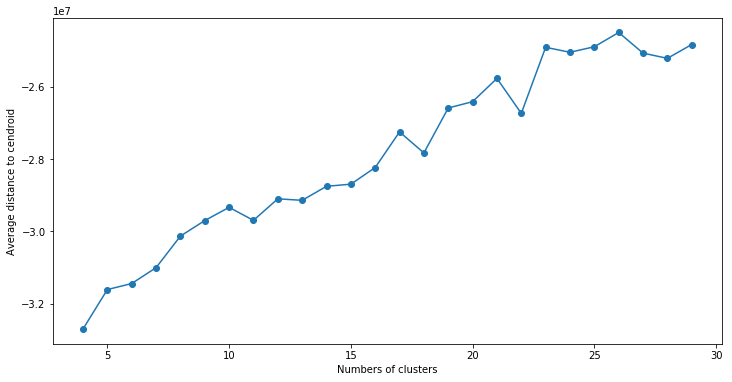

```python
# Investigate the change in within-cluster distance across number of clusters.
# HINT: Use matplotlib's plot function to visualize this relationship.

plt.figure(figsize=(12, 6))
plt.plot(clusters, scores, "-o")
plt.xlabel("Numbers of clusters")
plt.ylabel("Average distance to cendroid")
plt.show()
```

```python
# Re-fit the k-means model with the selected number of clusters and obtain
# cluster predictions for the general population demographics data.
kmeans = KMeans(n_clusters=11)
kmeans = kmeans.fit(X_pca)
preds = kmeans.predict(X_pca)
```

```python
kmeans.score(X_pca)
```

```
-28520776.589773558
```

### Discussion 3.1: Apply Clustering to General Population

KMeans was taking a very long time. This is why I decided to choose MiniBatchKmeans to find the number of clusters. This increases significantly the speed with aproxamtively the same scores.

I can't see an elbow in the graph. According to the infos, we had, I choose 11.

### Step 3.2: Apply All Steps to the Customer Data

Now that you have clusters and cluster centers for the general population, it's time to see how the customer data maps on to those clusters. Take care to not confuse this for re-fitting all of the models to the customer data. Instead, you're going to use the fits from the general population to clean, transform, and cluster the customer data. In the last step of the project, you will interpret how the general population fits apply to the customer data.

- Don't forget when loading in the customers data, that it is semicolon (`;`) delimited.
- Apply the same feature wrangling, selection, and engineering steps to the customer demographics using the `clean_data()` function you created earlier. (You can assume that the customer demographics data has similar meaning behind missing data patterns as the general demographics data.)
- Use the sklearn objects from the general demographics data, and apply their transformations to the customers data. That is, you should not be using a `.fit()` or `.fit_transform()` method to re-fit the old objects, nor should you be creating new sklearn objects! Carry the data through the feature scaling, PCA, and clustering steps, obtaining cluster assignments for all of the data in the customer demographics data.

```python
# Load in the customer demographics data.
customers = pd.read_csv("Udacity_CUSTOMERS_Subset.csv", sep=";")
print("Shape:", customers.shape)
customers.columns
```

```
Shape: (191652, 85)
```

```
Index(['AGER_TYP', 'ALTERSKATEGORIE_GROB', 'ANREDE_KZ', 'CJT_GESAMTTYP',
       'FINANZ_MINIMALIST', 'FINANZ_SPARER', 'FINANZ_VORSORGER',
       'FINANZ_ANLEGER', 'FINANZ_UNAUFFAELLIGER', 'FINANZ_HAUSBAUER',
       'FINANZTYP', 'GEBURTSJAHR', 'GFK_URLAUBERTYP', 'GREEN_AVANTGARDE',
       'HEALTH_TYP', 'LP_LEBENSPHASE_FEIN', 'LP_LEBENSPHASE_GROB',
       'LP_FAMILIE_FEIN', 'LP_FAMILIE_GROB', 'LP_STATUS_FEIN',
       'LP_STATUS_GROB', 'NATIONALITAET_KZ', 'PRAEGENDE_JUGENDJAHRE',
       'RETOURTYP_BK_S', 'SEMIO_SOZ', 'SEMIO_FAM', 'SEMIO_REL', 'SEMIO_MAT',
       'SEMIO_VERT', 'SEMIO_LUST', 'SEMIO_ERL', 'SEMIO_KULT', 'SEMIO_RAT',
       'SEMIO_KRIT', 'SEMIO_DOM', 'SEMIO_KAEM', 'SEMIO_PFLICHT', 'SEMIO_TRADV',
       'SHOPPER_TYP', 'SOHO_KZ', 'TITEL_KZ', 'VERS_TYP', 'ZABEOTYP',
       'ALTER_HH', 'ANZ_PERSONEN', 'ANZ_TITEL', 'HH_EINKOMMEN_SCORE',
       'KK_KUNDENTYP', 'W_KEIT_KIND_HH', 'WOHNDAUER_2008',
       'ANZ_HAUSHALTE_AKTIV', 'ANZ_HH_TITEL', 'GEBAEUDETYP', 'KONSUMNAEHE',
       'MIN_GEBAEUDEJAHR', 'OST_WEST_KZ', 'WOHNLAGE', 'CAMEO_DEUG_2015',
       'CAMEO_DEU_2015', 'CAMEO_INTL_2015', 'KBA05_ANTG1', 'KBA05_ANTG2',
       'KBA05_ANTG3', 'KBA05_ANTG4', 'KBA05_BAUMAX', 'KBA05_GBZ', 'BALLRAUM',
       'EWDICHTE', 'INNENSTADT', 'GEBAEUDETYP_RASTER', 'KKK', 'MOBI_REGIO',
       'ONLINE_AFFINITAET', 'REGIOTYP', 'KBA13_ANZAHL_PKW', 'PLZ8_ANTG1',
       'PLZ8_ANTG2', 'PLZ8_ANTG3', 'PLZ8_ANTG4', 'PLZ8_BAUMAX', 'PLZ8_HHZ',
       'PLZ8_GBZ', 'ARBEIT', 'ORTSGR_KLS9', 'RELAT_AB'],
      dtype='object')
```

```python
customers.isnull().sum()
```

```
AGER_TYP                     0
ALTERSKATEGORIE_GROB         0
ANREDE_KZ                    0
CJT_GESAMTTYP             3213
FINANZ_MINIMALIST            0
FINANZ_SPARER                0
FINANZ_VORSORGER             0
FINANZ_ANLEGER               0
FINANZ_UNAUFFAELLIGER        0
FINANZ_HAUSBAUER             0
FINANZTYP                    0
GEBURTSJAHR                  0
GFK_URLAUBERTYP           3213
GREEN_AVANTGARDE             0
HEALTH_TYP                   0
LP_LEBENSPHASE_FEIN       3213
LP_LEBENSPHASE_GROB       3213
LP_FAMILIE_FEIN           3213
LP_FAMILIE_GROB           3213
LP_STATUS_FEIN            3213
LP_STATUS_GROB            3213
NATIONALITAET_KZ             0
PRAEGENDE_JUGENDJAHRE        0
RETOURTYP_BK_S            3213
SEMIO_SOZ                    0
SEMIO_FAM                    0
SEMIO_REL                    0
SEMIO_MAT                    0
SEMIO_VERT                   0
SEMIO_LUST                   0
                         ...
OST_WEST_KZ              49927
WOHNLAGE                 49927
CAMEO_DEUG_2015          50428
CAMEO_DEU_2015           50428
CAMEO_INTL_2015          50428
KBA05_ANTG1              55980
KBA05_ANTG2              55980
KBA05_ANTG3              55980
KBA05_ANTG4              55980
KBA05_BAUMAX             55980
KBA05_GBZ                55980
BALLRAUM                 49959
EWDICHTE                 49959
INNENSTADT               49959
GEBAEUDETYP_RASTER       49927
KKK                      54260
MOBI_REGIO               55980
ONLINE_AFFINITAET         3213
REGIOTYP                 54260
KBA13_ANZAHL_PKW         51281
PLZ8_ANTG1               52764
PLZ8_ANTG2               52764
PLZ8_ANTG3               52764
PLZ8_ANTG4               52764
PLZ8_BAUMAX              52764
PLZ8_HHZ                 52764
PLZ8_GBZ                 52764
ARBEIT                   50476
ORTSGR_KLS9              50476
RELAT_AB                 50476
Length: 85, dtype: int64
```

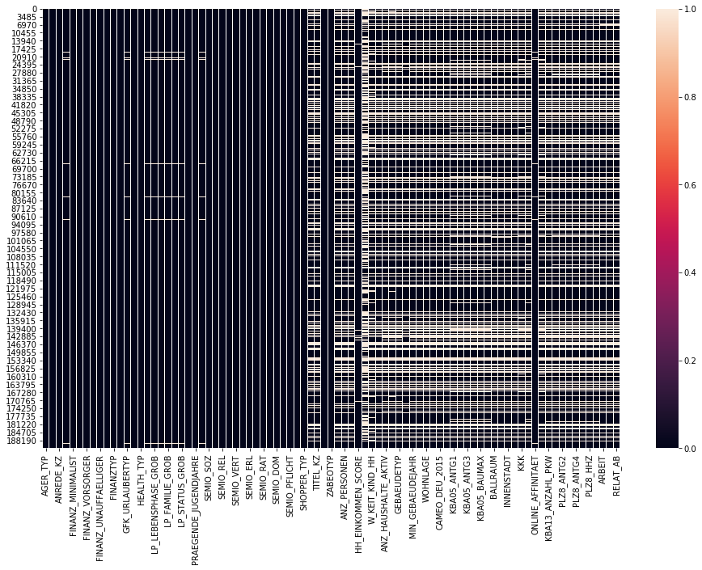

```python
width = 16
height = 10
plt.figure(figsize=(width, height))
sns.heatmap(customers.isnull())
```

```python
# Apply preprocessing, feature transformation, and clustering from the general
# demographics onto the customer data, obtaining cluster predictions for the
# customer demographics data.
customers_cleaned = clean_data(customers)
```

```
(191652, 85)
Step 1.1.1: Convert Missing Value Codes to NaNs
(191652, 85)
Step 1.1.2: Assess Missing Data in Each Column
(191652, 81)
Step 1.1.3: Assess Missing Data in Each Row
(137486, 81)
Step 1.2.1: Re-Encode Categorical Features
(137486, 89)
(137486, 132)
Step 1.2.2: Engineer Mixed-Type Features
(137486, 133)
```

```python
print("Shape:", customers_cleaned.shape)
print("Columns:", customers_cleaned.columns)
customers_cleaned.head()
```

```
Shape: (137486, 134)
Columns: Index(['ALTERSKATEGORIE_GROB', 'ANREDE_KZ', 'CJT_GESAMTTYP',
       'FINANZ_MINIMALIST', 'FINANZ_SPARER', 'FINANZ_VORSORGER',
       'FINANZ_ANLEGER', 'FINANZ_UNAUFFAELLIGER', 'FINANZ_HAUSBAUER',
       'FINANZTYP',
       ...
       'CAMEO_DEU_2015_8D', 'CAMEO_DEU_2015_9A', 'CAMEO_DEU_2015_9B',
       'CAMEO_DEU_2015_9C', 'CAMEO_DEU_2015_9D', 'CAMEO_DEU_2015_9E',
       'PRAEGENDE_JUGENDJAHRE_MOVEMENT', 'PRAEGENDE_JUGENDJAHRE_DECADES',
       'CAMEO_INTL_2015_WEALTH', 'CAMEO_INTL_2015_LIFE_STAGE'],
      dtype='object', length=134)
```

|  | ALTERSKATEGORIE_GROB | ANREDE_KZ | CJT_GESAMTTYP | FINANZ_MINIMALIST | FINANZ_SPARER | FINANZ_VORSORGER | FINANZ_ANLEGER | FINANZ_UNAUFFAELLIGER | FINANZ_HAUSBAUER | FINANZTYP | ... | CAMEO_DEU_2015_8D | CAMEO_DEU_2015_9A | CAMEO_DEU_2015_9B | CAMEO_DEU_2015_9C | CAMEO_DEU_2015_9D | CAMEO_DEU_2015_9E | PRAEGENDE_JUGENDJAHRE_MOVEMENT | PRAEGENDE_JUGENDJAHRE_DECADES | CAMEO_INTL_2015_WEALTH | CAMEO_INTL_2015_LIFE_STAGE |
| --- | --- | --- | --- | --- | --- | --- | --- | --- | --- | --- | --- | --- | --- | --- | --- | --- | --- | --- | --- | --- | --- |
| 0 | 4.0 | 1 | 5.0 | 5 | 1 | 5 | 1 | 2 | 2 | 2 | ... | 0.0 | 0.0 | 0.0 | 0.0 | 0.0 | 0.0 | 0.0 | 50.0 | 1.0 | 3.0 |
| 2 | 4.0 | 2 | 2.0 | 5 | 1 | 5 | 1 | 4 | 4 | 2 | ... | 0.0 | 0.0 | 0.0 | 0.0 | 0.0 | 0.0 | 0.0 | 50.0 | 3.0 | 4.0 |
| 3 | 4.0 | 1 | 2.0 | 5 | 1 | 5 | 2 | 1 | 2 | 6 | ... | 0.0 | 0.0 | 0.0 | 0.0 | 0.0 | 0.0 | 1.0 | 40.0 | 2.0 | 4.0 |
| 4 | 3.0 | 1 | 6.0 | 3 | 1 | 4 | 4 | 5 | 2 | 2 | ... | 0.0 | 0.0 | 0.0 | 0.0 | 0.0 | 0.0 | 1.0 | 70.0 | 4.0 | 1.0 |
| 5 | 3.0 | 1 | 4.0 | 5 | 1 | 5 | 1 | 2 | 3 | 5 | ... | 0.0 | 0.0 | 0.0 | 0.0 | 0.0 | 0.0 | 0.0 | 50.0 | 3.0 | 4.0 |

5 rows × 134 columns

```python
(customers_cleaned.isnull().sum(axis=1)>0).sum()
```

```
66619
```

```python
# customers_imputed = imputer.transform(customers_cleaned)
print("Shape cleaned data:", customers_cleaned.shape)
customers_imputed = customers_cleaned.dropna()
print("Shape imputed data:", customers_imputed.shape)
```

```
Shape cleaned data: (137486, 134)
Shape imputed data: (70867, 134)
```

```python
customers_scaled = scaler.transform(customers_imputed)
customers_scaled = pd.DataFrame(customers_scaled)
customers_scaled.head()
```

|  | 0 | 1 | 2 | 3 | 4 | 5 | 6 | 7 | 8 | 9 | ... | 124 | 125 | 126 | 127 | 128 | 129 | 130 | 131 | 132 | 133 |
| --- | --- | --- | --- | --- | --- | --- | --- | --- | --- | --- | --- | --- | --- | --- | --- | --- | --- | --- | --- | --- | --- |
| 0 | 0.236274 | -1.031268 | 1.613955 | -0.059820 | -1.178093 | 0.446803 | 0.830383 | 1.713269 | -0.791842 | -0.930444 | ... | -0.154404 | -0.16341 | -0.193417 | -0.179469 | -0.192087 | -0.064085 | 0.571232 | -0.333095 | 0.496574 | -1.272792 |
| 1 | 1.218116 | -1.031268 | -1.050275 | 1.412253 | -1.178093 | 1.150749 | -1.270189 | -1.163783 | -0.791842 | -0.930444 | ... | -0.154404 | -0.16341 | -0.193417 | -0.179469 | -0.192087 | -0.064085 | -1.750602 | -1.688373 | -0.871840 | 0.072848 |
| 2 | 1.218116 | -1.031268 | -1.050275 | 1.412253 | -1.178093 | 1.150749 | -1.270189 | -0.444520 | -0.791842 | 0.520400 | ... | -0.154404 | -0.16341 | -0.193417 | -0.179469 | -0.192087 | -0.064085 | -1.750602 | -1.688373 | -1.556048 | 1.418488 |
| 3 | 0.236274 | -1.031268 | -0.384217 | 1.412253 | -0.496830 | 0.446803 | -1.270189 | 0.274743 | -1.520303 | -0.930444 | ... | -0.154404 | -0.16341 | -0.193417 | -0.179469 | -0.192087 | -0.064085 | -1.750602 | -0.333095 | -1.556048 | 1.418488 |
| 4 | 1.218116 | -1.031268 | -0.384217 | 1.412253 | -1.178093 | 1.150749 | -1.270189 | 0.274743 | -0.791842 | -0.930444 | ... | -0.154404 | -0.16341 | -0.193417 | -0.179469 | -0.192087 | -0.064085 | -1.750602 | -1.688373 | -1.556048 | 0.745668 |

5 rows × 134 columns

```python
customers_pca = pca.transform(customers_scaled)
```

```python
customers_clusters = kmeans.predict(customers_pca)
```

### Step 3.3: Compare Customer Data to Demographics Data

At this point, you have clustered data based on demographics of the general population of Germany, and seen how the customer data for a mail-order sales company maps onto those demographic clusters. In this final substep, you will compare the two cluster distributions to see where the strongest customer base for the company is.

Consider the proportion of persons in each cluster for the general population, and the proportions for the customers. If we think the company's customer base to be universal, then the cluster assignment proportions should be fairly similar between the two. If there are only particular segments of the population that are interested in the company's products, then we should see a mismatch from one to the other. If there is a higher proportion of persons in a cluster for the customer data compared to the general population (e.g. 5% of persons are assigned to a cluster for the general population, but 15% of the customer data is closest to that cluster's centroid) then that suggests the people in that cluster to be a target audience for the company. On the other hand, the proportion of the data in a cluster being larger in the general population than the customer data (e.g. only 2% of customers closest to a population centroid that captures 6% of the data) suggests that group of persons to be outside of the target demographics.

Take a look at the following points in this step:

- Compute the proportion of data points in each cluster for the general population and the customer data. Visualizations will be useful here: both for the individual dataset proportions, but also to visualize the ratios in cluster representation between groups. Seaborn's [`countplot()`](https://seaborn.pydata.org/generated/seaborn.countplot.html) or [`barplot()`](https://seaborn.pydata.org/generated/seaborn.barplot.html) function could be handy.
  - Recall the analysis you performed in step 1.1.3 of the project, where you separated out certain data points from the dataset if they had more than a specified threshold of missing values. If you found that this group was qualitatively different from the main bulk of the data, you should treat this as an additional data cluster in this analysis. Make sure that you account for the number of data points in this subset, for both the general population and customer datasets, when making your computations!
- Which cluster or clusters are overrepresented in the customer dataset compared to the general population? Select at least one such cluster and infer what kind of people might be represented by that cluster. Use the principal component interpretations from step 2.3 or look at additional components to help you make this inference. Alternatively, you can use the `.inverse_transform()` method of the PCA and StandardScaler objects to transform centroids back to the original data space and interpret the retrieved values directly.
- Perform a similar investigation for the underrepresented clusters. Which cluster or clusters are underrepresented in the customer dataset compared to the general population, and what kinds of people are typified by these clusters?

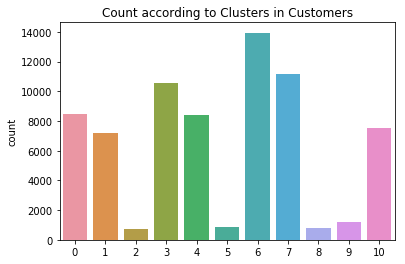

```python
# Compare the proportion of data in each cluster for the customer data to the
# proportion of data in each cluster for the general population.
plt.title("Count according to Clusters in Customers")
sns.countplot(customers_clusters)
```

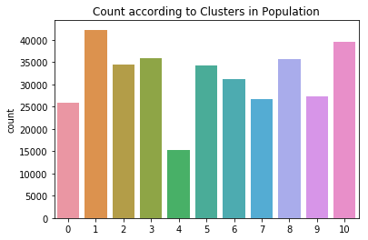

```python
plt.title("Count according to Clusters in Population")
sns.countplot(preds)
```

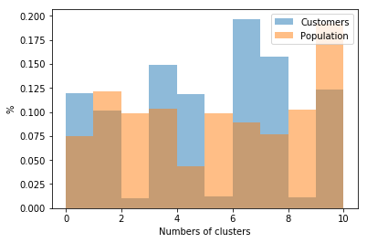

```python
plt.hist(customers_clusters, weights=np.ones(len(customers_clusters)) / len(customers_clusters), alpha=0.5, label="Customers")
plt.hist(preds, weights=np.ones(len(preds)) / len(preds), alpha=0.5, label="Population")
plt.xlabel("Numbers of clusters")
plt.ylabel("%")
plt.legend(loc="upper right")
plt.show()
```

```python
customers_df = pd.DataFrame(customers_clusters,columns=['Cluster']).reset_index().groupby('Cluster').count()/len(customers_clusters)*100
population_df = pd.DataFrame(preds,columns=['Cluster']).reset_index().groupby('Cluster').count()/len(preds)*100

diff_df = customers_df - population_df
```

```python
customers_df.head()
```

| Cluster | index |
| --- | --- |
| 0 | 11.935033 |
| 1 | 10.148588 |
| 2 | 1.014577 |
| 3 | 14.871520 |
| 4 | 11.878589 |

```python
population_df.head()
```

| Cluster | index |
| --- | --- |
| 0 | 7.456098 |
| 1 | 12.136731 |
| 2 | 9.879710 |
| 3 | 10.324623 |
| 4 | 4.373876 |

```python
diff_df
```

| Cluster | index |
| --- | --- |
| 0 | 4.478936 |
| 1 | -1.988143 |
| 2 | -8.865133 |
| 3 | 4.546897 |
| 4 | 7.504713 |
| 5 | -8.618264 |
| 6 | 10.734016 |
| 7 | 8.110408 |
| 8 | -9.105046 |
| 9 | -6.111465 |
| 10 | -0.686918 |

```python
# What kinds of people are part of a cluster that is overrepresented in the
# customer data compared to the general population?
diff_df['index'].nlargest(5)
```

```
Cluster
6    10.734016
7     8.110408
4     7.504713
3     4.546897
0     4.478936
Name: index, dtype: float64
```

are over represented in customers.

```python
# What kinds of people are part of a cluster that is underrepresented in the
# customer data compared to the general population?
diff_df['index'].nsmallest(5)
```

```
Cluster
8   -9.105046
2   -8.865133
5   -8.618264
9   -6.111465
1   -1.988143
Name: index, dtype: float64
```

are underrepresented in the customer data.

```python
# Analysis of cluster 6, overrepresented in customers
cluster_6 = kmeans.cluster_centers_[6]
cluster_6_serie = pd.Series(cluster_6)
cluster_6_serie.shape
```

```
(60,)
```

```python
cluster_6_inversed = pd.Series(pca.inverse_transform(cluster_6_serie))
print(cluster_6_inversed.shape)
columns_names = customers_imputed.columns.values
cluster_6_inversed.index = columns_names
cluster_6_inversed.sort_values(ascending=False)[:3]
```

```
(134,)
```

```
LP_LEBENSPHASE_FEIN    1.443184
LP_LEBENSPHASE_GROB    1.426857
LP_FAMILIE_GROB        1.321962
dtype: float64
```

- LP_LEBENSPHASE_FEIN: Life stage: High = Top earners
- LP_FAMILIE_GROB: Family Type: High = multiperson household

Cluster 6 shows big families with high incomes

```python
# Analysis of cluster 1, underrepresented in customers
cluster_1 = kmeans.cluster_centers_[1]
cluster_1_serie = pd.Series(cluster_1)
cluster_1_inversed = pd.Series(pca.inverse_transform(cluster_1_serie))
print(cluster_1_inversed.shape)
columns_names = customers_imputed.columns.values
cluster_1_inversed.index = columns_names
cluster_1_inversed.sort_values(ascending=False)[:3]
```

```
(134,)
```

```
SEMIO_ERL           1.080939
FINANZ_HAUSBAUER    1.016814
SEMIO_KAEM          0.944329
dtype: float64
```

### Discussion 3.3: Compare Customer Data to Demographics Data

I experienced one major difficulty. The thresholds I chose to remove columns and rows were too high from the population datasets. Then when I cleaned customers datas, I did not have enough columns to put into the Scaler. This is why I choose to simply drop missing values only after cleaning data.

A deeper analysis can be conducted along the other clusters.

The next steps would be to take another approaching missing values. We could use an Imputer with a most_frequent strategy.

> Congratulations on making it this far in the project! Before you finish, make sure to check through the entire notebook from top to bottom to make sure that your analysis follows a logical flow and all of your findings are documented in **Discussion** cells. Once you've checked over all of your work, you should export the notebook as an HTML document to submit for evaluation. You can do this from the menu, navigating to **File -> Download as -> HTML (.html)**. You will submit both that document and this notebook for your project submission.